# Bittiger DS501 Capstone Project Report - Yulin Chen

Detailed code can be found from [here](https://github.com/cl12102783/capstone/blob/master/original-yulin-kerkel.ipynb).

## Problem

The [Home Credit Default Risk competition](https://www.kaggle.com/c/home-credit-default-risk#description) is a supervised classification machine learning task in Kaggle with deadline on Aug 29, 2018. The data is provided by [Home Credit](http://www.homecredit.net/about-us.aspx), a service dedicated to provided lines of credit (loans) to the unbanked population. The objective of this competition is to use historical financial and socioeconomic data to predict whether or not an applicant will be able to repay a loan. This is a standard supervised classification task. AUC is required to be used as the evaluation standard.

## Summary

In this capstone project report, it is divided into four major parts:

- **1. Data processing and Exploratory**:

  > One-hot encoding for multi-class object and Label encoding for binary object;  
  > Outlier replacement for time features;  
  > EDA using Correlation, KDEplot, pairplot;  
  > Data processing and combining for the hierachical data structures;  
  > Creating new features using mean, median, max, min, sum, count processing.
- **2. Feature Selection**:

  > Remove missing value > 75%;  
  > Remove collinearity > 0.9;  
  > Keep features with 95% cumulative feature importance using Light GBM;  
  > Reduce the feature size from 1639 to 363.
- **3. Feature Engineering**

  > Polynomial combination;  
  > Domain knowledge;  
  > Time processing;  
  > Reference to others from kernels in Kaggle;  
  > Overall AUC increases from 0.785135 to 0.790696.
- **4. Model tuning**

  > Using light GBM with 5-fold cross validation and early stopping;  
  > the overall AUC increases from 0.790696 to **0.793270**

Finally, the test prediction ranks top 30% in the Kaggle leaderboard ranking.

## Dataset

There are 7 different data files:

- **application_train/application_test**: the main training and testing data with information about each loan application at Home Credit. Every loan has its own row and is identified by the `SK_ID_CURR`. The training application data comes with the `TARGET` with indicating 0: the loan was repaid and 1: the loan was not repaid.
- **bureau**: data concerning client's previous credits from other financial institutions. Each previous credit has its own row in bureau and is identified by the `SK_ID_BUREAU`, Each loan in the application data (`SK_ID_CURR`) can have multiple previous credits.
- **bureau_balance**: monthly data about the previous credits in bureau. Each row is one month balance of a previous credit, and a single previous credit (`SK_ID_BUREAU`) can have multiple rows, one for each month balance of the credit length.
- **previous_application**: previous applications for loans at Home Credit of clients who have loans in the application data. Each current loan in the application data (`SK_ID_CURR`) can have multiple previous loans. Each previous application has one row and is identified by the feature `SK_ID_PREV`.
- **POS_CASH_BALANCE**: monthly data about previous point of sale or cash loans clients have had with Home Credit. Each row is one month of a previous point of sale or cash loan, and a single previous loan (`SK_ID_PREV`) can have many rows.
- **installments_payment**: payment history for previous loans at Home Credit. There is one row for every made payment and one row for every missed payment.
- **credit_card_balance**: monthly data about previous credit cards clients have had with Home Credit. Each row is one month of a credit card balance, and a single previous loan (`SK_ID_PREV`) can have many rows.

The diagram below (provided by Home Credit) shows how the tables are related.

[figure not shown]

## 1. Data Processing and Exploratory

### 1.1 Application Train/Test Data

#### The dimension of training and testing data:

```python
train.shape, test.shape
```

```
((307511, 122), (48744, 121))
```

```python
train.head()
```

|  | SK_ID_CURR | TARGET | NAME_CONTRACT_TYPE | CODE_GENDER | FLAG_OWN_CAR | FLAG_OWN_REALTY | CNT_CHILDREN | AMT_INCOME_TOTAL | AMT_CREDIT | AMT_ANNUITY | ... | FLAG_DOCUMENT_18 | FLAG_DOCUMENT_19 | FLAG_DOCUMENT_20 | FLAG_DOCUMENT_21 | AMT_REQ_CREDIT_BUREAU_HOUR | AMT_REQ_CREDIT_BUREAU_DAY | AMT_REQ_CREDIT_BUREAU_WEEK | AMT_REQ_CREDIT_BUREAU_MON | AMT_REQ_CREDIT_BUREAU_QRT | AMT_REQ_CREDIT_BUREAU_YEAR |
| --- | --- | --- | --- | --- | --- | --- | --- | --- | --- | --- | --- | --- | --- | --- | --- | --- | --- | --- | --- | --- | --- |
| 0 | 100002 | 1 | Cash loans | M | N | Y | 0 | 202500.0 | 406597.5 | 24700.5 | ... | 0 | 0 | 0 | 0 | 0.0 | 0.0 | 0.0 | 0.0 | 0.0 | 1.0 |
| 1 | 100003 | 0 | Cash loans | F | N | N | 0 | 270000.0 | 1293502.5 | 35698.5 | ... | 0 | 0 | 0 | 0 | 0.0 | 0.0 | 0.0 | 0.0 | 0.0 | 0.0 |
| 2 | 100004 | 0 | Revolving loans | M | Y | Y | 0 | 67500.0 | 135000.0 | 6750.0 | ... | 0 | 0 | 0 | 0 | 0.0 | 0.0 | 0.0 | 0.0 | 0.0 | 0.0 |
| 3 | 100006 | 0 | Cash loans | F | N | Y | 0 | 135000.0 | 312682.5 | 29686.5 | ... | 0 | 0 | 0 | 0 | NaN | NaN | NaN | NaN | NaN | NaN |
| 4 | 100007 | 0 | Cash loans | M | N | Y | 0 | 121500.0 | 513000.0 | 21865.5 | ... | 0 | 0 | 0 | 0 | 0.0 | 0.0 | 0.0 | 0.0 | 0.0 | 0.0 |

5 rows × 122 columns

```python
test.head()
```

|  | SK_ID_CURR | NAME_CONTRACT_TYPE | CODE_GENDER | FLAG_OWN_CAR | FLAG_OWN_REALTY | CNT_CHILDREN | AMT_INCOME_TOTAL | AMT_CREDIT | AMT_ANNUITY | AMT_GOODS_PRICE | ... | FLAG_DOCUMENT_18 | FLAG_DOCUMENT_19 | FLAG_DOCUMENT_20 | FLAG_DOCUMENT_21 | AMT_REQ_CREDIT_BUREAU_HOUR | AMT_REQ_CREDIT_BUREAU_DAY | AMT_REQ_CREDIT_BUREAU_WEEK | AMT_REQ_CREDIT_BUREAU_MON | AMT_REQ_CREDIT_BUREAU_QRT | AMT_REQ_CREDIT_BUREAU_YEAR |
| --- | --- | --- | --- | --- | --- | --- | --- | --- | --- | --- | --- | --- | --- | --- | --- | --- | --- | --- | --- | --- | --- |
| 0 | 100001 | Cash loans | F | N | Y | 0 | 135000.0 | 568800.0 | 20560.5 | 450000.0 | ... | 0 | 0 | 0 | 0 | 0.0 | 0.0 | 0.0 | 0.0 | 0.0 | 0.0 |
| 1 | 100005 | Cash loans | M | N | Y | 0 | 99000.0 | 222768.0 | 17370.0 | 180000.0 | ... | 0 | 0 | 0 | 0 | 0.0 | 0.0 | 0.0 | 0.0 | 0.0 | 3.0 |
| 2 | 100013 | Cash loans | M | Y | Y | 0 | 202500.0 | 663264.0 | 69777.0 | 630000.0 | ... | 0 | 0 | 0 | 0 | 0.0 | 0.0 | 0.0 | 0.0 | 1.0 | 4.0 |
| 3 | 100028 | Cash loans | F | N | Y | 2 | 315000.0 | 1575000.0 | 49018.5 | 1575000.0 | ... | 0 | 0 | 0 | 0 | 0.0 | 0.0 | 0.0 | 0.0 | 0.0 | 3.0 |
| 4 | 100038 | Cash loans | M | Y | N | 1 | 180000.0 | 625500.0 | 32067.0 | 625500.0 | ... | 0 | 0 | 0 | 0 | NaN | NaN | NaN | NaN | NaN | NaN |

5 rows × 121 columns

#### Examine the distribution of the target column:

```
0    282686
1     24825
Name: TARGET, dtype: int64
```

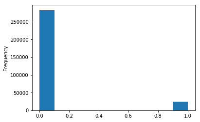

```python
# Counts the category in train data. Herein 1 means default, while 0 means repaid on time.
print(train['TARGET'].value_counts())
train['TARGET'].plot.hist()
```

**From above, we can see it is an imbalance class problem. Far more loans were repaid on time than not repaid.**

#### Column types:

```python
 # Distribution of datatypes
train.dtypes.value_counts()
```

```
float64    65
int64      41
object     16
dtype: int64
```

#### Unique values of object columns:

```python
# Number of unique classes in each object column
train.select_dtypes("object").apply(pd.Series.nunique, axis = 0)
```

```
NAME_CONTRACT_TYPE             2
CODE_GENDER                    3
FLAG_OWN_CAR                   2
FLAG_OWN_REALTY                2
NAME_TYPE_SUITE                7
NAME_INCOME_TYPE               8
NAME_EDUCATION_TYPE            5
NAME_FAMILY_STATUS             6
NAME_HOUSING_TYPE              6
OCCUPATION_TYPE               18
WEEKDAY_APPR_PROCESS_START     7
ORGANIZATION_TYPE             58
FONDKAPREMONT_MODE             4
HOUSETYPE_MODE                 3
WALLSMATERIAL_MODE             7
EMERGENCYSTATE_MODE            2
dtype: int64
```

**From above we know most of the categorical variables have a relatively small number of unique entries.**

#### Encoding categorical variables:

In this project, label encoding (LabelEncoder in Scikit-Learn) is used for any binary categorical variables, and one-hot encoding (pandas get_dummies) is used for others.

```python
# Create a label encoding object
le = LabelEncoder()
le_count = 0

# Iterate through columns
for col in train:
    if train[col].dtype == 'object':
        # If 2 or fewer unique categories
        if len(list(train[col].unique())) <= 2:
            # Train on the training data
            le.fit(train[col])
            # Transform both training and testing data
            train[col] = le.transform(train[col])
            test[col] = le.transform(test[col])

            # Keep track of how many columns were label encoded
            le_count += 1

print('%d columns were label encoded.' % le_count)
```

```
3 columns were label encoded.
```

```python
# One-hot encoding of categorical variables
train = pd.get_dummies(train)
test = pd.get_dummies(test)

print('Train data shape:',train.shape)
print('Test data shape:',test.shape)
```

```
Train data shape: (307511, 243)
Test data shape: (48744, 239)
```

#### Aligning train and test data

Since the feature numbers are different between the train and test data due to the unseen categories in either of them. So we need to align the dataframes by removing the columns that exist uncommonly.

```python
# Keep the target in the train data first
train_target = train['TARGET']

# Align the train and test data, keep only columns present in both dataframes
train, test = train.align(test, join = 'inner', axis = 1)

# Add the target back to the train
train['TARGET'] = train_target

print('Train data shape:', train.shape)
print('Test data shape:', test.shape)
```

```
Train data shape: (307511, 240)
Test data shape: (48744, 239)
```

#### Time variables processing:

One probelm we want to be on the lookout for when doing EDA is anomalies with in the data. These may be due to mistyped numbers, errors in measuing equipments, or they could be valid but extreme measurements, or outliers out of the acceptable range. Here we could use `describe` method to checkout the stats of a column.

First, let's use **DAYS_BIRTH** as an example to explore the nature.

```python
# Since DAYS_BIRTH is negative due to the recording relative to the current loan application.
# We multiply -1 and divide the number of days in a year.
(train['DAYS_BIRTH'] / -365).describe()
```

```
count    307511.000000
mean         43.936973
std          11.956133
min          20.517808
25%          34.008219
50%          43.150685
75%          53.923288
max          69.120548
Name: DAYS_BIRTH, dtype: float64
```

The ages look reasonable with no outliers out of either the low or high end.

Next, let's take a look at the **DAYS_EMPLOYED**:

```
count    307511.000000
mean        174.835742
std         387.056895
min         -49.073973
25%          -7.561644
50%          -3.323288
75%          -0.791781
max        1000.665753
Name: DAYS_EMPLOYED, dtype: float64
```

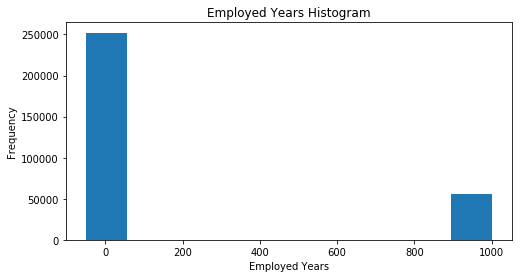

```python
print((train['DAYS_EMPLOYED'] / 365).describe())
(train['DAYS_EMPLOYED']/365).plot.hist(title = 'Employed Years Histogram');
plt.xlabel('Employed Years');
```

The above for the employed years is unreasonable that the max value is around 1000 years!

Further describe the information of the anomalies:

```python
anom = train[train['DAYS_EMPLOYED'] == train['DAYS_EMPLOYED'].max()]
non_anom = train[train['DAYS_EMPLOYED'] != train['DAYS_EMPLOYED'].max()]

print('Non-anomalies default on %0.2f%% of loans' % (100 * non_anom['TARGET'].mean()))
print('Anomalies default on %0.2f%% of loans' % (100 * anom['TARGET'].mean()))
print('There are %d anomalies with the same extreme value of %d days' %
      (len(anom),train['DAYS_EMPLOYED'].max()))
```

```
Non-anomalies default on 8.66% of loans
Anomalies default on 5.40% of loans
There are 55374 anomalies with the same extreme value of 365243 days
```

It turns out that the anomalies have a lower rate of default. In this case, since all the anormalies have exactly the same maximum value, we need to fill them with the same value in case all of them share something in common. By the importance of this characteristic, I will fill in the anomalous values with NAN (np.nan) and create a new boolean column indicating whether or not the value was anomalous.

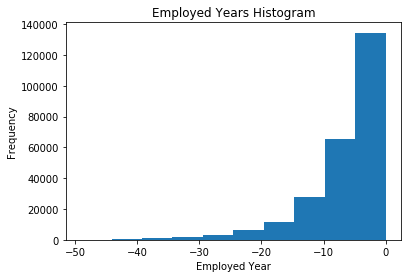

```python
# Create an anomalous flag column
train['DAYS_EMPLOYED_ANOM'] = train['DAYS_EMPLOYED'] == train['DAYS_EMPLOYED'].max()

# Replace the anomalous values with NAN
train['DAYS_EMPLOYED'].replace({train['DAYS_EMPLOYED'].max(): np.nan}, inplace = True)

(train['DAYS_EMPLOYED']/365).plot.hist(title = 'Employed Years Histogram');
plt.xlabel('Employed Year');
```

From the plot we can see the distribution looks to be in line with what we would expect.

Now let's process the same operation for the testing data:

```python
# Same operation for the test data
test['DAYS_EMPLOYED_ANOM'] = test['DAYS_EMPLOYED'] == test['DAYS_EMPLOYED'].max()
test['DAYS_EMPLOYED'].replace({test['DAYS_EMPLOYED'].max(): np.nan}, inplace = True)
print('%d anomalies of test data out of %d entries' % (test["DAYS_EMPLOYED_ANOM"].sum(), len(test)))
```

```
9274 anomalies of test data out of 48744 entries
```

#### Replace outliers for Other Dataframes

There are a number of features with the extreme value of *365243* related to **DAYS**, also in other dataframes. Let's replace them with NAN.

```python
import re

def replace_day_outliers(df):
    """Replace 365243 with np.nan in any columns with DAYS"""
    for col in df.columns:
        if "DAYS" in col:
            df[col] = df[col].replace({365243: np.nan})

    return df

# Replace all the day outliers
train = replace_day_outliers(train)
test = replace_day_outliers(test)
bu = replace_day_outliers(bu)
bu_blc = replace_day_outliers(bu_blc)
cred_blc = replace_day_outliers(cred_blc)
pos_blc = replace_day_outliers(pos_blc)
pr_app = replace_day_outliers(pr_app)
ins_pay = replace_day_outliers(ins_pay)
```

#### Correlations:

Here we will check Pearson correlations between the features and target by using **corr** although the correlation coefficient is not the greatest method to represent "relevance" of a feature. It will give us an idea of possible relationships within the data. And the results can let us focus more on those important features used for feature enginering shown later.

```python
correlations = train.corr()['TARGET'].sort_values()

 # Display correlations
print('Most Positive Correlations:\n', correlations.tail(15))
print('\nMost Negative Correlations:\n', correlations.head(15))
```

```
Most Positive Correlations:
 OCCUPATION_TYPE_Laborers                             0.043019
FLAG_DOCUMENT_3                                      0.044346
REG_CITY_NOT_LIVE_CITY                               0.044395
FLAG_EMP_PHONE                                       0.045982
NAME_EDUCATION_TYPE_Secondary / secondary special    0.049824
REG_CITY_NOT_WORK_CITY                               0.050994
DAYS_ID_PUBLISH                                      0.051457
CODE_GENDER_M                                        0.054713
DAYS_LAST_PHONE_CHANGE                               0.055218
NAME_INCOME_TYPE_Working                             0.057481
REGION_RATING_CLIENT                                 0.058899
REGION_RATING_CLIENT_W_CITY                          0.060893
DAYS_EMPLOYED                                        0.074958
DAYS_BIRTH                                           0.078239
TARGET                                               1.000000
Name: TARGET, dtype: float64

Most Negative Correlations:
 EXT_SOURCE_3                           -0.178919
EXT_SOURCE_2                           -0.160472
EXT_SOURCE_1                           -0.155317
NAME_EDUCATION_TYPE_Higher education   -0.056593
CODE_GENDER_F                          -0.054704
NAME_INCOME_TYPE_Pensioner             -0.046209
DAYS_EMPLOYED_ANOM                     -0.045987
ORGANIZATION_TYPE_XNA                  -0.045987
FLOORSMAX_AVG                          -0.044003
FLOORSMAX_MEDI                         -0.043768
FLOORSMAX_MODE                         -0.043226
EMERGENCYSTATE_MODE_No                 -0.042201
HOUSETYPE_MODE_block of flats          -0.040594
AMT_GOODS_PRICE                        -0.039645
REGION_POPULATION_RELATIVE             -0.037227
Name: TARGET, dtype: float64
```

It shows that the **DAYS_BIRTH** is the most positively correlated feature. But actually its value is negative, it means that elder people is less likely to default. For the convenience, we change it to absolute value.

Meanwhile, the 3 strongest negatively correlated features are **EXT_SOURCE_3**, **EXT_SOURCE_2** and **EXT_SOURCE_1**. According to the documentation, these three features represent a "normalized score from external data source".

#### Effect of Age on Repayment:

```python
# Use absolute value for the DAYS_BIRTH feature
train['DAYS_BIRTH']=abs(train['DAYS_BIRTH'])
train['DAYS_BIRTH'].corr(train['TARGET'])
```

```
-0.07823930830982712
```

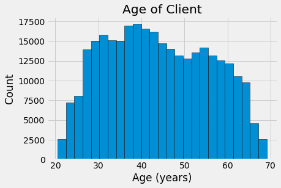

```python
# Plot the distribution of ages in years
```

By itself, the distribution of age does not tell us much other than that there are no outliers as all the ages are reasonable. To visualize the effect of the age on the target, we will next make a kernel density estimation plot (KDE) colored by the value of the target. I will use the seaborn kdeplot for this graph.

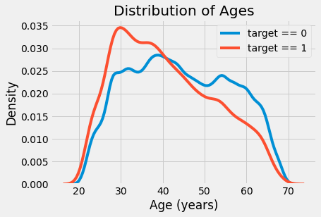

```python
# KDE plot of loans that were repaid on time and not on time
```

The target == 1 curve skews towards the younger end of the range. Although this is not a significant correlation (-0.07 correlation coefficient), this variable is likely going to be useful in a machine learning model because it does affect the target. Let's look at this relationship in another way: average failure to repay loans by age bracket.

To make this graph, first we cut the age category into bins of 5 years each. Then, for each bin, we calculate the average value of the target, which tells us the ratio of loans that were not repaid in each age category.

```python
# Age information into a separate dataframe
age_data = train[['TARGET', 'DAYS_BIRTH']]
age_data['YEARS_BIRTH'] = age_data['DAYS_BIRTH'] / 365

# Bin the age data
age_data['YEARS_BINNED'] = pd.cut(age_data['YEARS_BIRTH'], bins = np.linspace(20, 70, num = 11))
age_data.head(10)
```

|  | TARGET | DAYS_BIRTH | YEARS_BIRTH | YEARS_BINNED |
| --- | --- | --- | --- | --- |
| 0 | 1 | 9461 | 25.920548 | (25.0, 30.0] |
| 1 | 0 | 16765 | 45.931507 | (45.0, 50.0] |
| 2 | 0 | 19046 | 52.180822 | (50.0, 55.0] |
| 3 | 0 | 19005 | 52.068493 | (50.0, 55.0] |
| 4 | 0 | 19932 | 54.608219 | (50.0, 55.0] |
| 5 | 0 | 16941 | 46.413699 | (45.0, 50.0] |
| 6 | 0 | 13778 | 37.747945 | (35.0, 40.0] |
| 7 | 0 | 18850 | 51.643836 | (50.0, 55.0] |
| 8 | 0 | 20099 | 55.065753 | (55.0, 60.0] |
| 9 | 0 | 14469 | 39.641096 | (35.0, 40.0] |

```python
# Group by the bin and calculate averages
age_groups  = age_data.groupby('YEARS_BINNED').mean()
age_groups
```

| YEARS_BINNED | TARGET | DAYS_BIRTH | YEARS_BIRTH |
| --- | --- | --- | --- |
| (20.0, 25.0] | 0.123036 | 8532.795625 | 23.377522 |
| (25.0, 30.0] | 0.111436 | 10155.219250 | 27.822518 |
| (30.0, 35.0] | 0.102814 | 11854.848377 | 32.479037 |
| (35.0, 40.0] | 0.089414 | 13707.908253 | 37.555913 |
| (40.0, 45.0] | 0.078491 | 15497.661233 | 42.459346 |
| (45.0, 50.0] | 0.074171 | 17323.900441 | 47.462741 |
| (50.0, 55.0] | 0.066968 | 19196.494791 | 52.593136 |
| (55.0, 60.0] | 0.055314 | 20984.262742 | 57.491131 |
| (60.0, 65.0] | 0.052737 | 22780.547460 | 62.412459 |
| (65.0, 70.0] | 0.037270 | 24292.614340 | 66.555108 |

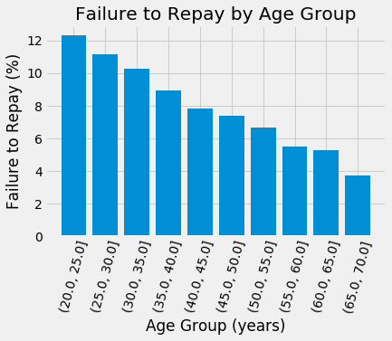

```python
# Graph the age bins and the average of the target as a bar plot
plt.bar(age_groups.index.astype(str), 100 * age_groups['TARGET'])

# Plot labeling
plt.xticks(rotation = 75); plt.xlabel('Age Group (years)'); plt.ylabel('Failure to Repay (%)')
plt.title('Failure to Repay by Age Group');
```

It is clear that young applicants are more likely to fail repayment. The youngest three bins are more than 10% failure, while the oldest age group is below 5%.

Based on the above analysis such as correlations with TARGET, we know **EXT_SOURCE1**, **EXT_SOURCE2**, **EXT_SOURCE3**, and **DAYS_BIRTH** are most important features in application data. Let's check their mutual relations:

```python
# Extract the EXT_SOURCE variables and show correlations
ext_data = train[['TARGET', 'EXT_SOURCE_1', 'EXT_SOURCE_2', 'EXT_SOURCE_3', 'DAYS_BIRTH']]
ext_data_corrs = ext_data.corr()
ext_data_corrs
```

|  | TARGET | EXT_SOURCE_1 | EXT_SOURCE_2 | EXT_SOURCE_3 | DAYS_BIRTH |
| --- | --- | --- | --- | --- | --- |
| TARGET | 1.000000 | -0.155317 | -0.160472 | -0.178919 | -0.078239 |
| EXT_SOURCE_1 | -0.155317 | 1.000000 | 0.213982 | 0.186846 | 0.600610 |
| EXT_SOURCE_2 | -0.160472 | 0.213982 | 1.000000 | 0.109167 | 0.091996 |
| EXT_SOURCE_3 | -0.178919 | 0.186846 | 0.109167 | 1.000000 | 0.205478 |
| DAYS_BIRTH | -0.078239 | 0.600610 | 0.091996 | 0.205478 | 1.000000 |

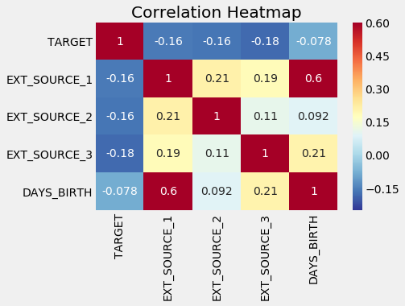

```python
# Heatmap of correlations
sns.heatmap(ext_data_corrs, cmap = plt.cm.RdYlBu_r, vmin = -0.25, annot = True, vmax = 0.6)
plt.title('Correlation Heatmap');
```

All three **EXT_SOURCE** features have negative correlations with the target, indicating that as the value of the **EXT_SOURCE** increases, the client is more likely to repay the loan. We can also see that **DAYS_BIRTH** is positively correlated with **EXT_SOURCE_1** indicating that maybe one of the factors in this score is the client age.

Next we can look at the distribution of each of these features colored by the value of the target using *kdeplot*. This will let us visualize the effect of this variable on the target.

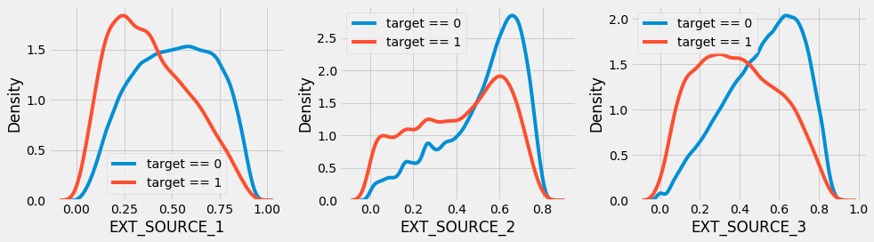

```python
plt.tight_layout(h_pad = 2.5)
```

**EXT_SOURCE_3** displays the greatest difference between the values of the target. We can clearly see that this feature has some relationship to the likelihood of an applicant to repay a loan.

#### Pairs Plot:

We can make a pairs plot of the **EXT_SOURCE** variables and the **DAYS_BIRTH** variable. The Pairs Plot is a great exploration tool because it lets us see relationships between multiple pairs of variables as well as distributions of single variables. Here we are using the *seaborn* visualization library and the *PairGrid* function to create a Pairs Plot with scatterplots on the upper triangle, histograms on the diagonal, and 2D kernel density plots and correlation coefficients on the lower triangle.

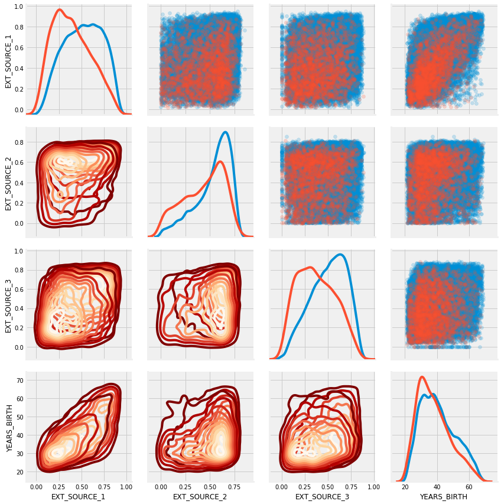

```python
# Pairs plot
```

In this plot, the red indicates loans that were not repaid and the blue are loans that are paid. We can see the different relationships within the data. There does appear to be a moderate positive linear relationship between the **EXT_SOURCE_1** and the **DAYS_BIRTH** (or equivalently **YEARS_BIRTH**), indicating that this feature may take into account the age of the client.

### 1.2 Bureau and Bureau_balance data

The two files are for financial data at other financial institutions.

```python
bu.head()
```

|  | SK_ID_CURR | SK_ID_BUREAU | CREDIT_ACTIVE | CREDIT_CURRENCY | DAYS_CREDIT | CREDIT_DAY_OVERDUE | DAYS_CREDIT_ENDDATE | DAYS_ENDDATE_FACT | AMT_CREDIT_MAX_OVERDUE | CNT_CREDIT_PROLONG | AMT_CREDIT_SUM | AMT_CREDIT_SUM_DEBT | AMT_CREDIT_SUM_LIMIT | AMT_CREDIT_SUM_OVERDUE | CREDIT_TYPE | DAYS_CREDIT_UPDATE | AMT_ANNUITY |
| --- | --- | --- | --- | --- | --- | --- | --- | --- | --- | --- | --- | --- | --- | --- | --- | --- | --- |
| 0 | 215354 | 5714462 | Closed | currency 1 | -497 | 0 | -153.0 | -153.0 | NaN | 0 | 91323.0 | 0.0 | NaN | 0.0 | Consumer credit | -131 | NaN |
| 1 | 215354 | 5714463 | Active | currency 1 | -208 | 0 | 1075.0 | NaN | NaN | 0 | 225000.0 | 171342.0 | NaN | 0.0 | Credit card | -20 | NaN |
| 2 | 215354 | 5714464 | Active | currency 1 | -203 | 0 | 528.0 | NaN | NaN | 0 | 464323.5 | NaN | NaN | 0.0 | Consumer credit | -16 | NaN |
| 3 | 215354 | 5714465 | Active | currency 1 | -203 | 0 | NaN | NaN | NaN | 0 | 90000.0 | NaN | NaN | 0.0 | Credit card | -16 | NaN |
| 4 | 215354 | 5714466 | Active | currency 1 | -629 | 0 | 1197.0 | NaN | 77674.5 | 0 | 2700000.0 | NaN | NaN | 0.0 | Consumer credit | -21 | NaN |

```python
bu_blc.head()
```

|  | SK_ID_BUREAU | MONTHS_BALANCE | STATUS |
| --- | --- | --- | --- |
| 0 | 5715448 | 0 | C |
| 1 | 5715448 | -1 | C |
| 2 | 5715448 | -2 | C |
| 3 | 5715448 | -3 | C |
| 4 | 5715448 | -4 | C |

#### Counts of a client's previous loans

In this case we will:

- 1) group by the unique client, the SK_ID_CURR column;
- 2) perform a calculation on the grouped data such as taking the count, mean, median, max, and min of columns;
- 3) match the aggregated statistics to the appropriate client (left merge). We need to merge the original training data with the calculated stats on the SK_ID_CURR column which will insert NaN in any cell for which the client does not have the corresponding statistic.For the count variable, 0 will be filled for unmatched rows.

```python
# Groupby the client id (SK_ID_CURR), count the number of previous loans, and rename the column
previous_loan_counts = bu.groupby('SK_ID_CURR', as_index=False)['SK_ID_BUREAU'].count().rename(columns = {'SK_ID_BUREAU': 'previous_loan_counts'})
previous_loan_counts.head()
```

|  | SK_ID_CURR | previous_loan_counts |
| --- | --- | --- |
| 0 | 100001 | 7 |
| 1 | 100002 | 8 |
| 2 | 100003 | 4 |
| 3 | 100004 | 2 |
| 4 | 100005 | 3 |

```python
# Join to the training and testing dataframe
train = train.merge(previous_loan_counts, on = 'SK_ID_CURR', how = 'left')
test = test.merge(previous_loan_counts, on = 'SK_ID_CURR', how = 'left')

# Fill the missing values with 0
train['previous_loan_counts'] = train['previous_loan_counts'].fillna(0)
test['previous_loan_counts'] = test['previous_loan_counts'].fillna(0)
train.head()
```

|  | SK_ID_CURR | NAME_CONTRACT_TYPE | FLAG_OWN_CAR | FLAG_OWN_REALTY | CNT_CHILDREN | AMT_INCOME_TOTAL | AMT_CREDIT | AMT_ANNUITY | AMT_GOODS_PRICE | REGION_POPULATION_RELATIVE | ... | WALLSMATERIAL_MODE_Monolithic | WALLSMATERIAL_MODE_Others | WALLSMATERIAL_MODE_Panel | WALLSMATERIAL_MODE_Stone, brick | WALLSMATERIAL_MODE_Wooden | EMERGENCYSTATE_MODE_No | EMERGENCYSTATE_MODE_Yes | TARGET | DAYS_EMPLOYED_ANOM | previous_loan_counts |
| --- | --- | --- | --- | --- | --- | --- | --- | --- | --- | --- | --- | --- | --- | --- | --- | --- | --- | --- | --- | --- | --- |
| 0 | 100002 | 0 | 0 | True | 0 | 202500.0 | 406597.5 | 24700.5 | 351000.0 | 0.018801 | ... | 0 | 0 | 0 | True | 0 | True | 0 | True | False | 8.0 |
| 1 | 100003 | 0 | 0 | False | 0 | 270000.0 | 1293502.5 | 35698.5 | 1129500.0 | 0.003541 | ... | 0 | 0 | 0 | False | 0 | True | 0 | False | False | 4.0 |
| 2 | 100004 | 1 | 1 | True | 0 | 67500.0 | 135000.0 | 6750.0 | 135000.0 | 0.010032 | ... | 0 | 0 | 0 | False | 0 | False | 0 | False | False | 2.0 |
| 3 | 100006 | 0 | 0 | True | 0 | 135000.0 | 312682.5 | 29686.5 | 297000.0 | 0.008019 | ... | 0 | 0 | 0 | False | 0 | False | 0 | False | False | 0.0 |
| 4 | 100007 | 0 | 0 | True | 0 | 121500.0 | 513000.0 | 21865.5 | 513000.0 | 0.028663 | ... | 0 | 0 | 0 | False | 0 | False | 0 | False | False | 1.0 |

5 rows × 242 columns

```
The correlation between previous_loan_counts and the TARGET is -0.0100
Median value for loan that was not repaid = 3.0000
Median value for loan that was repaid =     4.0000
```

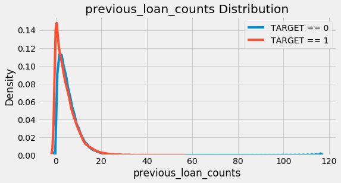

```python
kde_target('previous_loan_counts', train)
```

From this it's difficult to tell if this variable will be important. The correlation coefficient is extremely weak and there is almost no noticeable difference in the distributions.

#### Aggregating numeric/categorical Columns

Two core functions are defined for the aggregation of numeric and categorical columns. They can also be repeatedly used for column processing in other files.

- agg_numeric: calculate aggregation statistics (median, mean, max, min, sum) for numeric variables.
- count_categorical: compute counts and normalized counts of each category in a categorical variable

#### Aggregated Stats of Bureau Dataframe

```python
bu_agg_new = agg_numeric(bu.drop(columns = ['SK_ID_BUREAU']), 'SK_ID_CURR', 'bu')
bu_agg_new.head()
```

| SK_ID_CURR | bu_DAYS_CREDIT_sum | bu_DAYS_ENDDATE_FACT_sum | bu_DAYS_CREDIT_min | bu_DAYS_CREDIT_ENDDATE_min | bu_DAYS_ENDDATE_FACT_min | bu_DAYS_CREDIT_median | bu_DAYS_ENDDATE_FACT_mean | bu_DAYS_CREDIT_mean | bu_DAYS_ENDDATE_FACT_median | bu_DAYS_CREDIT_UPDATE_sum | ... | bu_AMT_CREDIT_SUM_median | bu_AMT_CREDIT_SUM_mean | bu_AMT_CREDIT_SUM_DEBT_max | bu_AMT_CREDIT_SUM_max | bu_AMT_CREDIT_SUM_DEBT_sum | bu_AMT_CREDIT_SUM_sum | bu_AMT_CREDIT_MAX_OVERDUE_min | bu_AMT_CREDIT_MAX_OVERDUE_median | bu_AMT_CREDIT_MAX_OVERDUE_mean | bu_AMT_CREDIT_MAX_OVERDUE_max |
| --- | --- | --- | --- | --- | --- | --- | --- | --- | --- | --- | --- | --- | --- | --- | --- | --- | --- | --- | --- | --- | --- |
| 100001 | -5145 | -3302.0 | -1572 | -1329.0 | -1328.0 | -857.0 | -825.500000 | -735.000000 | -715.0 | -652 | ... | 168345.000000 | 207623.578125 | 373239.0 | 378000.000000 | 596686.5 | 1.453365e+06 | NaN | NaN | NaN | NaN |
| 100002 | -6992 | -4185.0 | -1437 | -1072.0 | -1185.0 | -1042.5 | -697.500000 | -874.000000 | -939.0 | -3999 | ... | 54130.500000 | 108131.945312 | 245781.0 | 450000.000000 | 245781.0 | 8.650556e+05 | 0.0 | 40.5 | 1681.029053 | 5043.64502 |
| 100003 | -5603 | -3292.0 | -2586 | -2434.0 | -2131.0 | -1205.5 | -1097.333374 | -1400.750000 | -621.0 | -3264 | ... | 92576.250000 | 254350.125000 | 0.0 | 810000.000000 | 0.0 | 1.017400e+06 | 0.0 | 0.0 | 0.000000 | 0.00000 |
| 100004 | -1734 | -1065.0 | -1326 | -595.0 | -683.0 | -867.0 | -532.500000 | -867.000000 | -532.5 | -1064 | ... | 94518.898438 | 94518.898438 | 0.0 | 94537.796875 | 0.0 | 1.890378e+05 | 0.0 | 0.0 | 0.000000 | 0.00000 |
| 100005 | -572 | -123.0 | -373 | -128.0 | -123.0 | -137.0 | -123.000000 | -190.666667 | -123.0 | -163 | ... | 58500.000000 | 219042.000000 | 543087.0 | 568800.000000 | 568408.5 | 6.571260e+05 | 0.0 | 0.0 | 0.000000 | 0.00000 |

5 rows × 60 columns

#### Counts of Bureau Dataframe

```python
bu_cat_counts = count_categorical(bu, 'SK_ID_CURR', 'bu')
bu_cat_counts.head()
```

| SK_ID_CURR | bu_CREDIT_TYPE_Mobile operator loan_mean | bu_CREDIT_TYPE_Mobile operator loan_sum | bu_CREDIT_TYPE_Loan for purchase of shares (margin lending)_mean | bu_CREDIT_TYPE_Loan for purchase of shares (margin lending)_sum | bu_CREDIT_ACTIVE_Bad debt_mean | bu_CREDIT_ACTIVE_Bad debt_sum | bu_CREDIT_TYPE_Interbank credit_mean | bu_CREDIT_TYPE_Interbank credit_sum | bu_CREDIT_TYPE_Real estate loan_mean | bu_CREDIT_TYPE_Real estate loan_sum | ... | bu_CREDIT_TYPE_Credit card_sum | bu_CREDIT_ACTIVE_Active_mean | bu_CREDIT_ACTIVE_Closed_mean | bu_CREDIT_TYPE_Consumer credit_mean | bu_CREDIT_CURRENCY_currency 1_mean | bu_CREDIT_ACTIVE_Active_sum | bu_CREDIT_ACTIVE_Closed_sum | bu_CREDIT_TYPE_Consumer credit_sum | bu_CREDIT_CURRENCY_currency 1_sum | bu_CREDIT_ACTIVE_Active_count |
| --- | --- | --- | --- | --- | --- | --- | --- | --- | --- | --- | --- | --- | --- | --- | --- | --- | --- | --- | --- | --- | --- |
| 100001 | 0.0 | 0 | 0.0 | 0 | 0.0 | 0 | 0.0 | 0 | 0.0 | 0 | ... | 0 | 0.428571 | 0.571429 | 1.000000 | 1.0 | 3 | 4 | 7 | 7 | 7 |
| 100002 | 0.0 | 0 | 0.0 | 0 | 0.0 | 0 | 0.0 | 0 | 0.0 | 0 | ... | 4 | 0.250000 | 0.750000 | 0.500000 | 1.0 | 2 | 6 | 4 | 8 | 8 |
| 100003 | 0.0 | 0 | 0.0 | 0 | 0.0 | 0 | 0.0 | 0 | 0.0 | 0 | ... | 2 | 0.250000 | 0.750000 | 0.500000 | 1.0 | 1 | 3 | 2 | 4 | 4 |
| 100004 | 0.0 | 0 | 0.0 | 0 | 0.0 | 0 | 0.0 | 0 | 0.0 | 0 | ... | 0 | 0.000000 | 1.000000 | 1.000000 | 1.0 | 0 | 2 | 2 | 2 | 2 |
| 100005 | 0.0 | 0 | 0.0 | 0 | 0.0 | 0 | 0.0 | 0 | 0.0 | 0 | ... | 1 | 0.666667 | 0.333333 | 0.666667 | 1.0 | 2 | 1 | 2 | 3 | 3 |

5 rows × 47 columns

#### Value counts of Bureau Balance dataframe by loan

```python
bu_blc = convert_types(bu_blc, print_info=True)
bu_blc = label_encode(bu_blc)
bu_blc.head()
```

```
Original Memory Usage: 0.66 gb.
New Memory Usage: 0.25 gb.
0 columns were label encoded.
```

|  | SK_ID_BUREAU | MONTHS_BALANCE | STATUS |
| --- | --- | --- | --- |
| 0 | 5715448 | 0 | C |
| 1 | 5715448 | -1 | C |
| 2 | 5715448 | -2 | C |
| 3 | 5715448 | -3 | C |
| 4 | 5715448 | -4 | C |

```python
# Categorical column processing
# Counts of each type of status for each previous loan
bu_blc_counts = count_categorical(bu_blc, 'SK_ID_BUREAU', 'bu_blc')
bu_blc_counts.head()
```

| SK_ID_BUREAU | bu_blc_STATUS_4_mean | bu_blc_STATUS_3_mean | bu_blc_STATUS_2_mean | bu_blc_STATUS_5_mean | bu_blc_STATUS_4_sum | bu_blc_STATUS_3_sum | bu_blc_STATUS_2_sum | bu_blc_STATUS_5_sum | bu_blc_STATUS_1_mean | bu_blc_STATUS_1_sum | bu_blc_STATUS_0_mean | bu_blc_STATUS_0_sum | bu_blc_STATUS_X_mean | bu_blc_STATUS_C_mean | bu_blc_STATUS_X_sum | bu_blc_STATUS_C_sum | bu_blc_STATUS_0_count |
| --- | --- | --- | --- | --- | --- | --- | --- | --- | --- | --- | --- | --- | --- | --- | --- | --- | --- |
| 5001709 | 0.0 | 0.0 | 0.0 | 0.0 | 0 | 0 | 0 | 0 | 0.0 | 0 | 0.000000 | 0 | 0.113402 | 0.886598 | 11 | 86 | 97 |
| 5001710 | 0.0 | 0.0 | 0.0 | 0.0 | 0 | 0 | 0 | 0 | 0.0 | 0 | 0.060241 | 5 | 0.361446 | 0.578313 | 30 | 48 | 83 |
| 5001711 | 0.0 | 0.0 | 0.0 | 0.0 | 0 | 0 | 0 | 0 | 0.0 | 0 | 0.750000 | 3 | 0.250000 | 0.000000 | 1 | 0 | 4 |
| 5001712 | 0.0 | 0.0 | 0.0 | 0.0 | 0 | 0 | 0 | 0 | 0.0 | 0 | 0.526316 | 10 | 0.000000 | 0.473684 | 0 | 9 | 19 |
| 5001713 | 0.0 | 0.0 | 0.0 | 0.0 | 0 | 0 | 0 | 0 | 0.0 | 0 | 0.000000 | 0 | 1.000000 | 0.000000 | 22 | 0 | 22 |

#### Aggregated stats of Bureau Balance dataframe by loan

```python
# Numeric column processing
# Calculate value count statistics for each `SK_ID_CURR`, which is merged then
bu_blc_agg = agg_numeric(bu_blc, 'SK_ID_BUREAU', 'bu_blc')
bu_blc_agg.head()
```

| SK_ID_BUREAU | bu_blc_MONTHS_BALANCE_sum | bu_blc_MONTHS_BALANCE_min | bu_blc_MONTHS_BALANCE_median | bu_blc_MONTHS_BALANCE_max |
| --- | --- | --- | --- | --- |
| 5001709 | -4656 | -96 | -48.0 | 0 |
| 5001710 | -3403 | -82 | -41.0 | 0 |
| 5001711 | -6 | -3 | -1.5 | 0 |
| 5001712 | -171 | -18 | -9.0 | 0 |
| 5001713 | -231 | -21 | -10.5 | 0 |

#### Aggregated Stats of Bureau Balance by Client

The above dataframes have the calculations done on each loan. Now we need to aggregate these for each client. We can do this by merging the dataframes together first. Then since all the variables are numeric in Bureau_Blance, we just need to aggregate the statistics again, this time grouping by the **SK_ID_CURR**.

```python
# Dataframe grouped by the loan
bu_by_loan = bu_blc_agg.merge(bu_blc_counts, right_index = True, left_on = 'SK_ID_BUREAU', how = 'outer')

# Merge to include the SK_ID_CURR
bu_by_loan = bu_by_loan.merge(bu[['SK_ID_BUREAU', 'SK_ID_CURR']], on = 'SK_ID_BUREAU', how = 'left')

bu_by_loan.head()
```

|  | SK_ID_BUREAU | bu_blc_MONTHS_BALANCE_sum | bu_blc_MONTHS_BALANCE_min | bu_blc_MONTHS_BALANCE_median | bu_blc_MONTHS_BALANCE_max | bu_blc_STATUS_4_mean | bu_blc_STATUS_3_mean | bu_blc_STATUS_2_mean | bu_blc_STATUS_5_mean | bu_blc_STATUS_4_sum | ... | bu_blc_STATUS_1_mean | bu_blc_STATUS_1_sum | bu_blc_STATUS_0_mean | bu_blc_STATUS_0_sum | bu_blc_STATUS_X_mean | bu_blc_STATUS_C_mean | bu_blc_STATUS_X_sum | bu_blc_STATUS_C_sum | bu_blc_STATUS_0_count | SK_ID_CURR |
| --- | --- | --- | --- | --- | --- | --- | --- | --- | --- | --- | --- | --- | --- | --- | --- | --- | --- | --- | --- | --- | --- |
| 0 | 5001709 | -4656 | -96 | -48.0 | 0 | 0.0 | 0.0 | 0.0 | 0.0 | 0 | ... | 0.0 | 0 | 0.000000 | 0 | 0.113402 | 0.886598 | 11 | 86 | 97 | NaN |
| 1 | 5001710 | -3403 | -82 | -41.0 | 0 | 0.0 | 0.0 | 0.0 | 0.0 | 0 | ... | 0.0 | 0 | 0.060241 | 5 | 0.361446 | 0.578313 | 30 | 48 | 83 | 162368.0 |
| 2 | 5001711 | -6 | -3 | -1.5 | 0 | 0.0 | 0.0 | 0.0 | 0.0 | 0 | ... | 0.0 | 0 | 0.750000 | 3 | 0.250000 | 0.000000 | 1 | 0 | 4 | 162368.0 |
| 3 | 5001712 | -171 | -18 | -9.0 | 0 | 0.0 | 0.0 | 0.0 | 0.0 | 0 | ... | 0.0 | 0 | 0.526316 | 10 | 0.000000 | 0.473684 | 0 | 9 | 19 | 162368.0 |
| 4 | 5001713 | -231 | -21 | -10.5 | 0 | 0.0 | 0.0 | 0.0 | 0.0 | 0 | ... | 0.0 | 0 | 0.000000 | 0 | 1.000000 | 0.000000 | 22 | 0 | 22 | 150635.0 |

5 rows × 23 columns

```python
bu_blc_by_client = agg_numeric(bu_by_loan.drop(columns = ['SK_ID_BUREAU']), 'SK_ID_CURR', 'client')
bu_blc_by_client.head()
```

| SK_ID_CURR | client_bu_blc_MONTHS_BALANCE_sum_sum | client_bu_blc_MONTHS_BALANCE_sum_min | client_bu_blc_MONTHS_BALANCE_sum_median | client_bu_blc_MONTHS_BALANCE_sum_mean | client_bu_blc_MONTHS_BALANCE_min_sum | client_bu_blc_MONTHS_BALANCE_median_sum | client_bu_blc_MONTHS_BALANCE_min_min | client_bu_blc_MONTHS_BALANCE_min_median | client_bu_blc_MONTHS_BALANCE_median_min | client_bu_blc_MONTHS_BALANCE_min_mean | ... | client_bu_blc_STATUS_C_sum_mean | client_bu_blc_STATUS_C_sum_median | client_bu_blc_STATUS_0_count_mean | client_bu_blc_STATUS_0_count_median | client_bu_blc_STATUS_X_sum_sum | client_bu_blc_STATUS_0_sum_sum | client_bu_blc_STATUS_C_sum_max | client_bu_blc_STATUS_0_count_max | client_bu_blc_STATUS_C_sum_sum | client_bu_blc_STATUS_0_count_sum |
| --- | --- | --- | --- | --- | --- | --- | --- | --- | --- | --- | --- | --- | --- | --- | --- | --- | --- | --- | --- | --- | --- |
| 100001.0 | -2800 | -1326 | -406.0 | -400.000000 | -165 | -82.5 | -51 | -28.0 | -25.5 | -23.571429 | ... | 15.714286 | 18.0 | 24.571429 | 29.0 | 30.0 | 31.0 | 44 | 52 | 110.0 | 172 |
| 100002.0 | -2701 | -632 | -424.0 | -337.625000 | -226 | -175.0 | -47 | -34.0 | -39.5 | -28.250000 | ... | 2.875000 | 2.0 | 13.750000 | 16.0 | 15.0 | 45.0 | 13 | 22 | 23.0 | 110 |
| 100005.0 | -91 | -78 | -10.0 | -30.333333 | -18 | -9.0 | -12 | -4.0 | -6.0 | -6.000000 | ... | 1.666667 | 0.0 | 7.000000 | 5.0 | 2.0 | 14.0 | 5 | 13 | 5.0 | 21 |
| 100010.0 | -3312 | -2610 | -1656.0 | -1656.000000 | -127 | -92.0 | -90 | -63.5 | -72.5 | -63.500000 | ... | 26.000000 | 26.0 | 36.000000 | 36.0 | 0.0 | 20.0 | 26 | 36 | 52.0 | 72 |
| 100013.0 | -6756 | -2346 | -1815.0 | -1689.000000 | -226 | -113.0 | -68 | -59.5 | -34.0 | -56.500000 | ... | 25.750000 | 29.5 | 57.500000 | 60.5 | 41.0 | 79.0 | 44 | 69 | 103.0 | 230 |

5 rows × 105 columns

#### Insert Computed Features into Training/Testing Data

```python
original_features = list(train.columns)
print('Original Number of Features: ', len(original_features))
```

```
Original Number of Features:  242
```

```python
# Training merge
# Merge with the value counts of bureau
train = train.merge(bu_cat_counts, on = 'SK_ID_CURR', how = 'left')

# Merge with the stats of bureau
train = train.merge(bu_agg_new, on = 'SK_ID_CURR', how = 'left')

# Merge with the monthly information grouped by client
train = train.merge(bu_blc_by_client, on = 'SK_ID_CURR', how = 'left')
#--------------------------------------------------
# Testing merge
# Merge with the value counts of bureau
test = test.merge(bu_cat_counts, on = 'SK_ID_CURR', how = 'left')

# Merge with the stats of bureau
test = test.merge(bu_agg_new, on = 'SK_ID_CURR', how = 'left')

# Merge with the value counts of bureau balance
test = test.merge(bu_blc_by_client, on = 'SK_ID_CURR', how = 'left')

print('Shape of New Testing Data: ', train.shape)
print('Shape of New Testing Data: ', test.shape)
```

```
Shape of New Testing Data:  (307511, 454)
Shape of New Testing Data:  (48744, 453)
```

### 1.3 Other Four Additional Dataframes

The definitions of the four additional data files are:

- **previous_application** (called previous): previous applications for loans at Home Credit of clients who have loans in the application data. Each current loan in the application data can have multiple previous loans. Each previous application has one row and is identified by the feature SK_ID_PREV.
- **POS_CASH_BALANCE** (called cash): monthly data about previous point of sale or cash loans clients have had with Home Credit. Each row is one month of a previous point of sale or cash loan, and a single previous loan can have many rows.
- **credit_card_balance** (called credit): monthly data about previous credit cards clients have had with Home Credit. Each row is one month of a credit card balance, and a single credit card can have many rows.
- **installments_payment** (called installments): payment history for previous loans at Home Credit. There is one row for every made payment and one row for every missed payment.

Our general approach will apply the two core functions (*agg_numeric* and *agg_categorical*) to these dataframes, grouping by the client id, **SK_ID_CURR**. For the **POS_CASH_balance**, **credit_card_balance**, and **installment_payments**, we can first group by the **SK_ID_PREV**, the unique id for the previous loan. Then we will group the resulting dataframe by the **SK_ID_CURR** to calculate the aggregation statistics for each client across all of their previous loans.

Let's deal with one dataframe at a time. First up is the previous_applications. This has one row for every previous loan a client had at Home Credit. A client can have multiple previous loans which is why we need to aggregate statistics for each client.

#### Previous_application

```python
# Change the type of object to categorical to save memory space
pr_app = convert_types(pr_app, print_info=True)
pr_app.head()
```

```
Original Memory Usage: 0.49 gb.
New Memory Usage: 0.16 gb.
```

|  | SK_ID_PREV | SK_ID_CURR | NAME_CONTRACT_TYPE | AMT_ANNUITY | AMT_APPLICATION | AMT_CREDIT | AMT_DOWN_PAYMENT | AMT_GOODS_PRICE | WEEKDAY_APPR_PROCESS_START | HOUR_APPR_PROCESS_START | ... | NAME_SELLER_INDUSTRY | CNT_PAYMENT | NAME_YIELD_GROUP | PRODUCT_COMBINATION | DAYS_FIRST_DRAWING | DAYS_FIRST_DUE | DAYS_LAST_DUE_1ST_VERSION | DAYS_LAST_DUE | DAYS_TERMINATION | NFLAG_INSURED_ON_APPROVAL |
| --- | --- | --- | --- | --- | --- | --- | --- | --- | --- | --- | --- | --- | --- | --- | --- | --- | --- | --- | --- | --- | --- |
| 0 | 2030495 | 271877 | Consumer loans | 1730.430054 | 17145.0 | 17145.0 | 0.0 | 17145.0 | SATURDAY | 15 | ... | Connectivity | 12.0 | middle | POS mobile with interest | NaN | -42.0 | 300.0 | -42.0 | -37.0 | 0.0 |
| 1 | 2802425 | 108129 | Cash loans | 25188.615234 | 607500.0 | 679671.0 | NaN | 607500.0 | THURSDAY | 11 | ... | XNA | 36.0 | low_action | Cash X-Sell: low | NaN | -134.0 | 916.0 | NaN | NaN | 1.0 |
| 2 | 2523466 | 122040 | Cash loans | 15060.735352 | 112500.0 | 136444.5 | NaN | 112500.0 | TUESDAY | 11 | ... | XNA | 12.0 | high | Cash X-Sell: high | NaN | -271.0 | 59.0 | NaN | NaN | 1.0 |
| 3 | 2819243 | 176158 | Cash loans | 47041.335938 | 450000.0 | 470790.0 | NaN | 450000.0 | MONDAY | 7 | ... | XNA | 12.0 | middle | Cash X-Sell: middle | NaN | -482.0 | -152.0 | -182.0 | -177.0 | 1.0 |
| 4 | 1784265 | 202054 | Cash loans | 31924.394531 | 337500.0 | 404055.0 | NaN | 337500.0 | THURSDAY | 9 | ... | XNA | 24.0 | high | Cash Street: high | NaN | NaN | NaN | NaN | NaN | NaN |

5 rows × 37 columns

```python
# Calculate aggregate statistics for each numeric column
previous_agg = agg_numeric(pr_app, 'SK_ID_CURR', 'prev')
print('Previous aggregation shape: ', previous_agg.shape)
previous_agg.head()
```

```
Previous aggregation shape:  (338857, 90)
```

| SK_ID_CURR | prev_DAYS_DECISION_sum | prev_DAYS_DECISION_min | prev_DAYS_DECISION_mean | prev_DAYS_DECISION_median | prev_DAYS_DECISION_max | prev_DAYS_FIRST_DUE_sum | prev_DAYS_FIRST_DUE_min | prev_DAYS_FIRST_DUE_mean | prev_DAYS_FIRST_DUE_median | prev_DAYS_FIRST_DUE_max | ... | prev_DAYS_FIRST_DRAWING_median | prev_DAYS_FIRST_DRAWING_max | prev_RATE_INTEREST_PRIMARY_min | prev_RATE_INTEREST_PRIMARY_median | prev_RATE_INTEREST_PRIMARY_mean | prev_RATE_INTEREST_PRIMARY_max | prev_RATE_INTEREST_PRIVILEGED_min | prev_RATE_INTEREST_PRIVILEGED_median | prev_RATE_INTEREST_PRIVILEGED_mean | prev_RATE_INTEREST_PRIVILEGED_max |
| --- | --- | --- | --- | --- | --- | --- | --- | --- | --- | --- | --- | --- | --- | --- | --- | --- | --- | --- | --- | --- | --- |
| 100001 | -1740 | -1740 | -1740.0 | -1740.0 | -1740 | -1709.0 | -1709.0 | -1709.000000 | -1709.0 | -1709.0 | ... | NaN | NaN | NaN | NaN | NaN | NaN | NaN | NaN | NaN | NaN |
| 100002 | -606 | -606 | -606.0 | -606.0 | -606 | -565.0 | -565.0 | -565.000000 | -565.0 | -565.0 | ... | NaN | NaN | NaN | NaN | NaN | NaN | NaN | NaN | NaN | NaN |
| 100003 | -3915 | -2341 | -1305.0 | -828.0 | -746 | -3823.0 | -2310.0 | -1274.333374 | -797.0 | -716.0 | ... | NaN | NaN | NaN | NaN | NaN | NaN | NaN | NaN | NaN | NaN |
| 100004 | -815 | -815 | -815.0 | -815.0 | -815 | -784.0 | -784.0 | -784.000000 | -784.0 | -784.0 | ... | NaN | NaN | NaN | NaN | NaN | NaN | NaN | NaN | NaN | NaN |
| 100005 | -1072 | -757 | -536.0 | -536.0 | -315 | -706.0 | -706.0 | -706.000000 | -706.0 | -706.0 | ... | NaN | NaN | NaN | NaN | NaN | NaN | NaN | NaN | NaN | NaN |

5 rows × 90 columns

```python
# Calculate value counts for each categorical column
previous_counts = count_categorical(pr_app, 'SK_ID_CURR', 'prev')
print('Previous counts shape: ', previous_counts.shape)
previous_counts.head()
```

```
Previous counts shape:  (338857, 285)
```

| SK_ID_CURR | prev_NAME_GOODS_CATEGORY_Animals_mean | prev_NAME_GOODS_CATEGORY_Animals_sum | prev_NAME_GOODS_CATEGORY_House Construction_mean | prev_NAME_GOODS_CATEGORY_House Construction_sum | prev_NAME_CASH_LOAN_PURPOSE_Refusal to name the goal_mean | prev_NAME_CASH_LOAN_PURPOSE_Refusal to name the goal_sum | prev_NAME_CASH_LOAN_PURPOSE_Money for a third person_mean | prev_NAME_CASH_LOAN_PURPOSE_Money for a third person_sum | prev_NAME_CASH_LOAN_PURPOSE_Hobby_mean | prev_NAME_CASH_LOAN_PURPOSE_Hobby_sum | ... | prev_CODE_REJECT_REASON_XAP_mean | prev_FLAG_LAST_APPL_PER_CONTRACT_Y_mean | prev_NAME_PORTFOLIO_POS_sum | prev_NAME_CONTRACT_TYPE_Consumer loans_sum | prev_NAME_CASH_LOAN_PURPOSE_XAP_sum | prev_NAME_PRODUCT_TYPE_XNA_sum | prev_NAME_CONTRACT_STATUS_Approved_sum | prev_CODE_REJECT_REASON_XAP_sum | prev_FLAG_LAST_APPL_PER_CONTRACT_Y_sum | prev_NAME_CONTRACT_TYPE_Cash loans_count |
| --- | --- | --- | --- | --- | --- | --- | --- | --- | --- | --- | --- | --- | --- | --- | --- | --- | --- | --- | --- | --- | --- |
| 100001 | 0.0 | 0 | 0.0 | 0 | 0.0 | 0 | 0.0 | 0 | 0.0 | 0 | ... | 1.0 | 1.0 | 1 | 1 | 1 | 1 | 1 | 1 | 1 | 1 |
| 100002 | 0.0 | 0 | 0.0 | 0 | 0.0 | 0 | 0.0 | 0 | 0.0 | 0 | ... | 1.0 | 1.0 | 1 | 1 | 1 | 1 | 1 | 1 | 1 | 1 |
| 100003 | 0.0 | 0 | 0.0 | 0 | 0.0 | 0 | 0.0 | 0 | 0.0 | 0 | ... | 1.0 | 1.0 | 2 | 2 | 2 | 2 | 3 | 3 | 3 | 3 |
| 100004 | 0.0 | 0 | 0.0 | 0 | 0.0 | 0 | 0.0 | 0 | 0.0 | 0 | ... | 1.0 | 1.0 | 1 | 1 | 1 | 1 | 1 | 1 | 1 | 1 |
| 100005 | 0.0 | 0 | 0.0 | 0 | 0.0 | 0 | 0.0 | 0 | 0.0 | 0 | ... | 1.0 | 1.0 | 1 | 1 | 1 | 2 | 1 | 2 | 2 | 2 |

5 rows × 285 columns

We can join the calculated dataframe to the main training dataframe using a merge. Then we should delete the calculated dataframes to avoid using too much of the kernel memory.

```python
# Merge in the previous information
train = train.merge(previous_counts, on ='SK_ID_CURR', how = 'left')
train = train.merge(previous_agg, on = 'SK_ID_CURR', how = 'left')
test = test.merge(previous_counts, on ='SK_ID_CURR', how = 'left')
test = test.merge(previous_agg, on = 'SK_ID_CURR', how = 'left')
# Remove variables to free memory
gc.enable()
del pr_app, previous_agg, previous_counts
gc.collect()
```

```
189
```

#### Monthly Cash Data

```python
pos_blc = convert_types(pos_blc, print_info=True)
pos_blc.head()
```

```
Original Memory Usage: 0.64 gb.
New Memory Usage: 0.29 gb.
```

|  | SK_ID_PREV | SK_ID_CURR | MONTHS_BALANCE | CNT_INSTALMENT | CNT_INSTALMENT_FUTURE | NAME_CONTRACT_STATUS | SK_DPD | SK_DPD_DEF |
| --- | --- | --- | --- | --- | --- | --- | --- | --- |
| 0 | 1803195 | 182943 | -31 | 48.0 | 45.0 | Active | 0 | 0 |
| 1 | 1715348 | 367990 | -33 | 36.0 | 35.0 | Active | 0 | 0 |
| 2 | 1784872 | 397406 | -32 | 12.0 | 9.0 | Active | 0 | 0 |
| 3 | 1903291 | 269225 | -35 | 48.0 | 42.0 | Active | 0 | 0 |
| 4 | 2341044 | 334279 | -35 | 36.0 | 35.0 | Active | 0 | 0 |

```python
cash_by_client = aggregate_client(pos_blc, group_vars = ['SK_ID_PREV', 'SK_ID_CURR'], df_names = ['cash', 'client'])
cash_by_client.head()
```

| SK_ID_CURR | client_cash_MONTHS_BALANCE_sum_sum | client_cash_MONTHS_BALANCE_min_sum | client_cash_MONTHS_BALANCE_mean_sum | client_cash_MONTHS_BALANCE_median_sum | client_cash_MONTHS_BALANCE_max_sum | client_cash_MONTHS_BALANCE_sum_min | client_cash_MONTHS_BALANCE_sum_mean | client_cash_MONTHS_BALANCE_sum_median | client_cash_MONTHS_BALANCE_sum_max | client_cash_MONTHS_BALANCE_min_min | ... | client_cash_SK_DPD_sum_sum | client_cash_CNT_INSTALMENT_FUTURE_max_sum | client_cash_NAME_CONTRACT_STATUS_Active_sum_sum | client_cash_CNT_INSTALMENT_min_sum | client_cash_CNT_INSTALMENT_mean_sum | client_cash_CNT_INSTALMENT_median_sum | client_cash_CNT_INSTALMENT_max_sum | client_cash_NAME_CONTRACT_STATUS_Active_count_sum | client_cash_CNT_INSTALMENT_FUTURE_sum_sum | client_cash_CNT_INSTALMENT_sum_sum |
| --- | --- | --- | --- | --- | --- | --- | --- | --- | --- | --- | --- | --- | --- | --- | --- | --- | --- | --- | --- | --- | --- |
| 100001 | -2887 | -669 | -653.0 | -653.0 | -637 | -378 | -320.777778 | -275.0 | -275 | -96 | ... | 28 | 28.0 | 32.0 | 36.0 | 36.000000 | 36.0 | 36.0 | 41 | 62.0 | 164.0 |
| 100002 | -3610 | -361 | -190.0 | -190.0 | -19 | -190 | -190.000000 | -190.0 | -190 | -19 | ... | 0 | 456.0 | 361.0 | 456.0 | 456.000000 | 456.0 | 456.0 | 361 | 5415.0 | 8664.0 |
| 100003 | -13240 | -1348 | -1226.0 | -1226.0 | -1104 | -858 | -472.857143 | -196.0 | -172 | -77 | ... | 0 | 288.0 | 256.0 | 248.0 | 283.000000 | 288.0 | 288.0 | 272 | 1608.0 | 2840.0 |
| 100004 | -408 | -108 | -102.0 | -102.0 | -96 | -102 | -102.000000 | -102.0 | -102 | -27 | ... | 0 | 16.0 | 12.0 | 12.0 | 15.000000 | 16.0 | 16.0 | 16 | 36.0 | 60.0 |
| 100005 | -2420 | -275 | -220.0 | -220.0 | -165 | -220 | -220.000000 | -220.0 | -220 | -25 | ... | 0 | 132.0 | 99.0 | 99.0 | 128.699997 | 132.0 | 132.0 | 121 | 792.0 | 1287.0 |

5 rows × 215 columns

```python
print('Cash by Client Shape: ', cash_by_client.shape)
train = train.merge(cash_by_client, on = 'SK_ID_CURR', how = 'left')
test = test.merge(cash_by_client, on = 'SK_ID_CURR', how = 'left')

gc.enable()
del pos_blc, cash_by_client
gc.collect()
```

```
Cash by Client Shape:  (337252, 215)
```

```
21
```

#### Monthly Credit Data

```python
cred_blc = convert_types(cred_blc, print_info = True)
cred_blc.head()
```

```
Original Memory Usage: 0.71 gb.
New Memory Usage: 0.34 gb.
```

|  | SK_ID_PREV | SK_ID_CURR | MONTHS_BALANCE | AMT_BALANCE | AMT_CREDIT_LIMIT_ACTUAL | AMT_DRAWINGS_ATM_CURRENT | AMT_DRAWINGS_CURRENT | AMT_DRAWINGS_OTHER_CURRENT | AMT_DRAWINGS_POS_CURRENT | AMT_INST_MIN_REGULARITY | ... | AMT_RECIVABLE | AMT_TOTAL_RECEIVABLE | CNT_DRAWINGS_ATM_CURRENT | CNT_DRAWINGS_CURRENT | CNT_DRAWINGS_OTHER_CURRENT | CNT_DRAWINGS_POS_CURRENT | CNT_INSTALMENT_MATURE_CUM | NAME_CONTRACT_STATUS | SK_DPD | SK_DPD_DEF |
| --- | --- | --- | --- | --- | --- | --- | --- | --- | --- | --- | --- | --- | --- | --- | --- | --- | --- | --- | --- | --- | --- |
| 0 | 2562384 | 378907 | -6 | 56.970001 | 135000 | 0.0 | 877.5 | 0.0 | 877.5 | 1700.324951 | ... | 0.000000 | 0.000000 | 0.0 | 1 | 0.0 | 1.0 | 35.0 | Active | 0 | 0 |
| 1 | 2582071 | 363914 | -1 | 63975.554688 | 45000 | 2250.0 | 2250.0 | 0.0 | 0.0 | 2250.000000 | ... | 64875.554688 | 64875.554688 | 1.0 | 1 | 0.0 | 0.0 | 69.0 | Active | 0 | 0 |
| 2 | 1740877 | 371185 | -7 | 31815.224609 | 450000 | 0.0 | 0.0 | 0.0 | 0.0 | 2250.000000 | ... | 31460.085938 | 31460.085938 | 0.0 | 0 | 0.0 | 0.0 | 30.0 | Active | 0 | 0 |
| 3 | 1389973 | 337855 | -4 | 236572.109375 | 225000 | 2250.0 | 2250.0 | 0.0 | 0.0 | 11795.759766 | ... | 233048.968750 | 233048.968750 | 1.0 | 1 | 0.0 | 0.0 | 10.0 | Active | 0 | 0 |
| 4 | 1891521 | 126868 | -1 | 453919.468750 | 450000 | 0.0 | 11547.0 | 0.0 | 11547.0 | 22924.890625 | ... | 453919.468750 | 453919.468750 | 0.0 | 1 | 0.0 | 1.0 | 101.0 | Active | 0 | 0 |

5 rows × 23 columns

```python
credit_by_client = aggregate_client(cred_blc, group_vars = ['SK_ID_PREV', 'SK_ID_CURR'], df_names = ['credit', 'client'])
credit_by_client.head()
```

| SK_ID_CURR | client_credit_MONTHS_BALANCE_sum_sum | client_credit_MONTHS_BALANCE_min_sum | client_credit_MONTHS_BALANCE_mean_sum | client_credit_MONTHS_BALANCE_median_sum | client_credit_MONTHS_BALANCE_sum_min | client_credit_MONTHS_BALANCE_sum_median | client_credit_MONTHS_BALANCE_sum_mean | client_credit_MONTHS_BALANCE_sum_max | client_credit_MONTHS_BALANCE_max_sum | client_credit_MONTHS_BALANCE_min_min | ... | client_credit_AMT_PAYMENT_CURRENT_mean_mean | client_credit_AMT_PAYMENT_CURRENT_mean_max | client_credit_AMT_PAYMENT_CURRENT_max_min | client_credit_AMT_PAYMENT_CURRENT_max_mean | client_credit_AMT_PAYMENT_CURRENT_max_median | client_credit_AMT_PAYMENT_CURRENT_max_max | client_credit_AMT_DRAWINGS_ATM_CURRENT_max_min | client_credit_AMT_DRAWINGS_ATM_CURRENT_max_mean | client_credit_AMT_DRAWINGS_ATM_CURRENT_max_median | client_credit_AMT_DRAWINGS_ATM_CURRENT_max_max |
| --- | --- | --- | --- | --- | --- | --- | --- | --- | --- | --- | --- | --- | --- | --- | --- | --- | --- | --- | --- | --- | --- |
| 100006 | -126 | -36 | -21.0 | -21.0 | -21 | -21 | -21.0 | -21 | -6 | -6 | ... | NaN | NaN | NaN | NaN | NaN | NaN | NaN | NaN | NaN | NaN |
| 100011 | -210826 | -5550 | -2849.0 | -2849.0 | -2849 | -2849 | -2849.0 | -2849 | -148 | -75 | ... | 4843.063965 | 4843.063965 | 55485.0 | 55485.0 | 55485.0 | 55485.0 | 180000.0 | 180000.0 | 180000.0 | 180000.0 |
| 100013 | -446976 | -9216 | -4656.0 | -4656.0 | -4656 | -4656 | -4656.0 | -4656 | -96 | -96 | ... | 7168.346191 | 7168.346191 | 153675.0 | 153675.0 | 153675.0 | 153675.0 | 157500.0 | 157500.0 | 157500.0 | 157500.0 |
| 100021 | -2890 | -306 | -170.0 | -170.0 | -170 | -170 | -170.0 | -170 | -34 | -18 | ... | NaN | NaN | NaN | NaN | NaN | NaN | NaN | NaN | NaN | NaN |
| 100023 | -480 | -88 | -60.0 | -60.0 | -60 | -60 | -60.0 | -60 | -32 | -11 | ... | NaN | NaN | NaN | NaN | NaN | NaN | NaN | NaN | NaN | NaN |

5 rows × 545 columns

```python
print('Credit by client shape: ', credit_by_client.shape)

train = train.merge(credit_by_client, on = 'SK_ID_CURR', how = 'left')
test = test.merge(credit_by_client, on = 'SK_ID_CURR', how = 'left')

gc.enable()
del cred_blc, credit_by_client
gc.collect()
```

```
Credit by client shape:  (103558, 545)
```

```
21
```

#### Installment Payments

```python
ins_pay = convert_types(ins_pay, print_info = True)
ins_pay.head()
```

```
Original Memory Usage: 0.98 gb.
New Memory Usage: 0.49 gb.
```

|  | SK_ID_PREV | SK_ID_CURR | NUM_INSTALMENT_VERSION | NUM_INSTALMENT_NUMBER | DAYS_INSTALMENT | DAYS_ENTRY_PAYMENT | AMT_INSTALMENT | AMT_PAYMENT | LATE_PAYMENT |
| --- | --- | --- | --- | --- | --- | --- | --- | --- | --- |
| 0 | 1054186 | 161674 | 1.0 | 6 | -1180.0 | -1187.0 | 6948.359863 | 6948.359863 | 0 |
| 1 | 1330831 | 151639 | 0.0 | 34 | -2156.0 | -2156.0 | 1716.525024 | 1716.525024 | 0 |
| 2 | 2085231 | 193053 | 2.0 | 1 | -63.0 | -63.0 | 25425.000000 | 25425.000000 | 0 |
| 3 | 2452527 | 199697 | 1.0 | 3 | -2418.0 | -2426.0 | 24350.130859 | 24350.130859 | 0 |
| 4 | 2714724 | 167756 | 1.0 | 2 | -1383.0 | -1366.0 | 2165.040039 | 2160.584961 | 1 |

```python
installments_by_client = aggregate_client(ins_pay, group_vars = ['SK_ID_PREV', 'SK_ID_CURR'], df_names = ['installments', 'client'])
installments_by_client.head()
```

| SK_ID_CURR | client_installments_DAYS_ENTRY_PAYMENT_sum_sum | client_installments_DAYS_INSTALMENT_sum_sum | client_installments_DAYS_ENTRY_PAYMENT_min_sum | client_installments_DAYS_INSTALMENT_min_sum | client_installments_DAYS_ENTRY_PAYMENT_median_sum | client_installments_DAYS_ENTRY_PAYMENT_mean_sum | client_installments_DAYS_INSTALMENT_mean_sum | client_installments_DAYS_INSTALMENT_median_sum | client_installments_DAYS_ENTRY_PAYMENT_max_sum | client_installments_DAYS_INSTALMENT_max_sum | ... | client_installments_AMT_INSTALMENT_sum_median | client_installments_AMT_PAYMENT_sum_median | client_installments_AMT_PAYMENT_sum_max | client_installments_AMT_INSTALMENT_sum_max | client_installments_AMT_PAYMENT_mean_sum | client_installments_AMT_INSTALMENT_mean_sum | client_installments_AMT_INSTALMENT_max_sum | client_installments_AMT_PAYMENT_max_sum | client_installments_AMT_PAYMENT_sum_sum | client_installments_AMT_INSTALMENT_sum_sum |
| --- | --- | --- | --- | --- | --- | --- | --- | --- | --- | --- | --- | --- | --- | --- | --- | --- | --- | --- | --- | --- | --- |
| 100001 | -52813.0 | -52598.0 | -15608.0 | -15584.0 | -15375.0 | -15365.0 | -15314.0 | -15314.0 | -15080.0 | -15044.0 | ... | 29250.900391 | 29250.900391 | 2.925090e+04 | 2.925090e+04 | 4.119593e+04 | 4.119593e+04 | 8.153775e+04 | 8.153775e+04 | 1.528387e+05 | 1.528387e+05 |
| 100002 | -113867.0 | -106495.0 | -11153.0 | -10735.0 | -5928.0 | -5993.0 | -5605.0 | -5605.0 | -931.0 | -475.0 | ... | 219625.703125 | 219625.703125 | 2.196257e+05 | 2.196257e+05 | 2.196257e+05 | 2.196257e+05 | 1.008781e+06 | 1.008781e+06 | 4.172888e+06 | 4.172888e+06 |
| 100003 | -367137.0 | -365546.0 | -37757.0 | -37514.0 | -34622.0 | -34633.0 | -34454.0 | -34454.0 | -31594.0 | -31394.0 | ... | 387113.937500 | 387113.937500 | 1.150977e+06 | 1.150977e+06 | 1.618865e+06 | 1.618865e+06 | 4.394102e+06 | 4.394102e+06 | 1.134881e+07 | 1.134881e+07 |
| 100004 | -6855.0 | -6786.0 | -2385.0 | -2352.0 | -2289.0 | -2285.0 | -2262.0 | -2262.0 | -2181.0 | -2172.0 | ... | 21288.464844 | 21288.464844 | 2.128846e+04 | 2.128846e+04 | 2.128846e+04 | 2.128846e+04 | 3.172189e+04 | 3.172189e+04 | 6.386539e+04 | 6.386539e+04 |
| 100005 | -49374.0 | -47466.0 | -6624.0 | -6354.0 | -5265.0 | -5486.0 | -5274.0 | -5274.0 | -4230.0 | -4194.0 | ... | 56161.843750 | 56161.843750 | 5.616184e+04 | 5.616184e+04 | 5.616184e+04 | 5.616184e+04 | 1.589062e+05 | 1.589062e+05 | 5.054566e+05 | 5.054566e+05 |

5 rows × 175 columns

```python
print('Installments by client shape: ', installments_by_client.shape)

train = train.merge(installments_by_client, on = 'SK_ID_CURR', how = 'left')
test = test.merge(installments_by_client, on = 'SK_ID_CURR', how = 'left')

gc.enable()
del ins_pay, installments_by_client
gc.collect()
```

```
Installments by client shape:  (339587, 175)
```

```
14
```

```python
print('Training Shape: ', train.shape)
print('Testing Shape: ', test.shape)
```

```
Training Shape:  (307511, 1640)
Testing Shape:  (48744, 1639)
```

```python
print(f'Training size: {return_size(train)}')
print(f'Testing size: {return_size(test)}')
```

```
Training size: 2.95
Testing size: 0.47
```

Now, we have finished data processing and EDA to merge into one data frame with 1639 features.

## 2. Feature Selection

Now we have too many features to handle modeling and there are still more features to be added by feature engineeing later. So let's do feature selection first for all the features we have. The actions are:

- Removed any columns with greater than 75% missing values in the train or test set
- Removed collinear features as measured by the correlation coefficient greater than 0.9
- Keep features with 95% cumulative feature importances in Light GBM

In the end of this section, the number of features is **reduced from 1639 to 363**. More details of the code can be viewed in the original code.

### 2.1 Missing Values

An important consideration is the missing values in the dataframe. Columns with too many missing values might have to be dropped. Here we define 75% as the missing percentage threshold.

### 2.2 Collinear Variables

Collinearity can cause high variance in the prediction. Here, collinearity > 0.9 is defined as the threshold to sift features.

```python
# Track columns to remove and columns already examined
cols_to_remove = []
cols_seen = []
cols_to_remove_pair = []

# Iterate through columns and correlated columns
for key, value in above_threshold_vars.items():
    # Keep track of columns already examined
    cols_seen.append(key)
    for x in value:
        if x == key:
            next
        else:
            # Only want to remove one in a pair
            if x not in cols_seen:
                cols_to_remove.append(x)
                cols_to_remove_pair.append(key)

cols_to_remove = list(set(cols_to_remove))
print('Number of columns to remove: ', len(cols_to_remove))
```

```
Number of columns to remove:  733
```

We can remove these columns from both the training and the testing datasets. By using Light GBM as the testbed, the deletion of these features is validated to be with better performance.

```python
train = train.drop(columns = cols_to_remove)
test = test.drop(columns = cols_to_remove)

print('Training Corrs Removed Shape: ', train.shape)
print('Testing Corrs Removed Shape: ', test.shape)
```

```
Training Corrs Removed Shape:  (307511, 907)
Testing Corrs Removed Shape:  (48744, 906)
```

### 2.3 Model feature importance

First, let's use the Light GBM with 5-fold cross validation to remove the features with 0 feature importance.

```python
submission, fi, metrics = model(train, test)
print('Baseline metrics')
print(metrics)
```

```
Training Data Shape:  (307511, 905)
Testing Data Shape:  (48744, 905)
Training until validation scores don't improve for 100 rounds.
[200]	valid's auc: 0.782309	train's auc: 0.830109
[400]	valid's auc: 0.783036	train's auc: 0.86802
Early stopping, best iteration is:
[332]	valid's auc: 0.783476	train's auc: 0.856238
Training until validation scores don't improve for 100 rounds.
[200]	valid's auc: 0.78599	train's auc: 0.829899
[400]	valid's auc: 0.787988	train's auc: 0.867913
[600]	valid's auc: 0.787738	train's auc: 0.896434
Early stopping, best iteration is:
[532]	valid's auc: 0.788367	train's auc: 0.887519
Training until validation scores don't improve for 100 rounds.
[200]	valid's auc: 0.778183	train's auc: 0.831216
[400]	valid's auc: 0.780852	train's auc: 0.868278
Early stopping, best iteration is:
[370]	valid's auc: 0.780978	train's auc: 0.863514
Training until validation scores don't improve for 100 rounds.
[200]	valid's auc: 0.784345	train's auc: 0.829831
[400]	valid's auc: 0.786439	train's auc: 0.86764
Early stopping, best iteration is:
[322]	valid's auc: 0.78654	train's auc: 0.854505
Training until validation scores don't improve for 100 rounds.
[200]	valid's auc: 0.784533	train's auc: 0.829792
[400]	valid's auc: 0.786233	train's auc: 0.867494
Early stopping, best iteration is:
[454]	valid's auc: 0.786654	train's auc: 0.876122
Baseline metrics
      fold     train     valid
0        0  0.856238  0.783476
1        1  0.887519  0.788367
2        2  0.863514  0.780978
3        3  0.854505  0.786540
4        4  0.876122  0.786654
5  overall  0.867579  0.785078
```

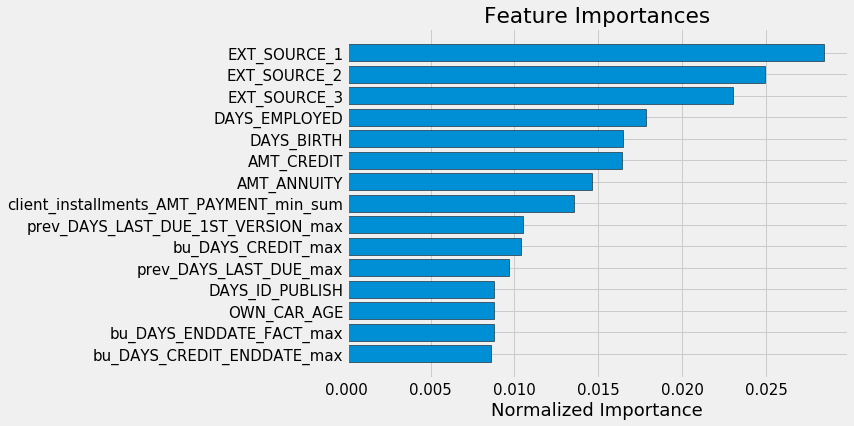

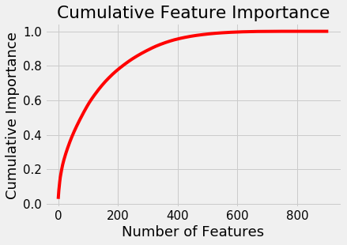

```
311 features required for 0.90 of cumulative importance
```

```python
fi_sorted = plot_feature_importances(fi,0.9)
```

From above, we can see the **EXT_SOURCE** series features and **DAYS_BIRTH** have high ranking as expected in our EDA. More importantly, there are 6 features built by myself ranked top 15. It means the creation is worth doing.

#### Remove features with zero importance

```python
# Find the features with zero importance
zero_features = list(fi[fi['importance'] == 0.0]['feature'])
print('There are %d features with 0.0 importance' % len(zero_features))
fi.tail()
```

```
There are 186 features with 0.0 importance
```

|  | feature | importance |
| --- | --- | --- |
| 900 | client_installments_AMT_PAYMENT_median_sum | 41.0 |
| 901 | client_installments_AMT_PAYMENT_sum_max | 33.8 |
| 902 | client_installments_AMT_PAYMENT_mean_sum | 25.4 |
| 903 | client_installments_AMT_INSTALMENT_max_sum | 31.8 |
| 904 | client_installments_AMT_PAYMENT_sum_sum | 37.2 |

Let's remove the features with zero importance.

```python
train = train.drop(columns = zero_features)
test = test.drop(columns = zero_features)

print('Training shape: ', train.shape)
print('Testing shape: ', test.shape)
```

```
Training shape:  (307511, 721)
Testing shape:  (48744, 720)
```

#### Repeated round removal for zero-importance features

Around 700 features still look heavy for us. Let's run more rounds to examoine zero feature importance features and remove them. It shows that 153 features are as the remnants to be deleted.

```python
second_round_zero_features, feature_importances = identify_zero_importance_features(train, train_target)
```

```
Training until validation scores don't improve for 100 rounds.
[200]	valid_0's auc: 0.780973
Early stopping, best iteration is:
[134]	valid_0's auc: 0.782583
Training until validation scores don't improve for 100 rounds.
[200]	valid_0's auc: 0.781951
Early stopping, best iteration is:
[133]	valid_0's auc: 0.783458

There are 153 features with 0.0 importance
```

```python
train = train.drop(columns = zero_features)
test = test.drop(columns = zero_features)

print('Training shape: ', train.shape)
print('Testing shape: ', test.shape)
```

```
Training shape:  (307511, 566)
Testing shape:  (48744, 566)
```

Let's make sure no zero importance features are left.

```python
third_round_zero_features, feature_importances = identify_zero_importance_features(train, train_target)
```

```
Training until validation scores don't improve for 100 rounds.
[200]	valid_0's auc: 0.781548
Early stopping, best iteration is:
[134]	valid_0's auc: 0.782583
Training until validation scores don't improve for 100 rounds.
[200]	valid_0's auc: 0.782451
Early stopping, best iteration is:
[133]	valid_0's auc: 0.783458

There are 0 features with 0.0 importance
```

#### Keep features with 95% cumulative feature importance:

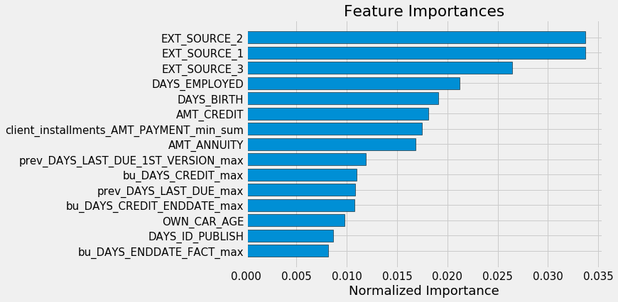

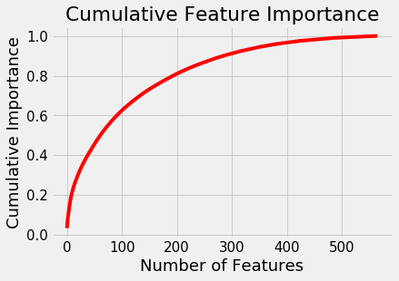

```
363 features required for 0.95 of cumulative importance
```

```python
norm_feature_importances = plot_feature_importances(feature_importances, threshold = 0.95)
```

```python
train['SK_ID_CURR'] = train_id_curr
train['TARGET'] = train_target
test['SK_ID_CURR'] = test_id_curr

submission, fi, metrics = model(train, test)
print('Baseline metrics')
print(metrics)
```

```
Training Data Shape:  (307511, 566)
Testing Data Shape:  (48744, 566)
Training until validation scores don't improve for 100 rounds.
[200]	valid's auc: 0.782469	train's auc: 0.83014
[400]	valid's auc: 0.784291	train's auc: 0.86748
Early stopping, best iteration is:
[375]	valid's auc: 0.784471	train's auc: 0.863622
Training until validation scores don't improve for 100 rounds.
[200]	valid's auc: 0.786645	train's auc: 0.829677
[400]	valid's auc: 0.787805	train's auc: 0.867254
Early stopping, best iteration is:
[315]	valid's auc: 0.78796	train's auc: 0.852741
Training until validation scores don't improve for 100 rounds.
[200]	valid's auc: 0.777425	train's auc: 0.830933
[400]	valid's auc: 0.779799	train's auc: 0.868268
Early stopping, best iteration is:
[415]	valid's auc: 0.779903	train's auc: 0.870656
Training until validation scores don't improve for 100 rounds.
[200]	valid's auc: 0.784186	train's auc: 0.829933
[400]	valid's auc: 0.785807	train's auc: 0.867712
Early stopping, best iteration is:
[329]	valid's auc: 0.785851	train's auc: 0.855669
Training until validation scores don't improve for 100 rounds.
[200]	valid's auc: 0.784776	train's auc: 0.829686
[400]	valid's auc: 0.786624	train's auc: 0.867224
Early stopping, best iteration is:
[403]	valid's auc: 0.786669	train's auc: 0.867689
Baseline metrics
      fold     train     valid
0        0  0.863622  0.784471
1        1  0.852741  0.787960
2        2  0.870656  0.779903
3        3  0.855669  0.785851
4        4  0.867689  0.786669
5  overall  0.862075  0.784939
```

Let's check the possibility of 95% cumulation.

```python
# Threshold for cumulative importance
threshold = 0.95

# Extract the features to keep
features_to_keep = list(norm_feature_importances[norm_feature_importances['cumulative_importance'] < threshold]['feature'])

# Create new datasets with smaller features
train_small = train[features_to_keep]
test_small = test[features_to_keep]
```

```python
train_small['TARGET'] = train_target
train_small['SK_ID_CURR'] = train_id_curr
test_small['SK_ID_CURR'] = test_id_curr
```

```python
submission, fi, metrics = model(train_small, test_small)
print('Baseline metrics')
print(metrics)
```

```
Training Data Shape:  (307511, 362)
Testing Data Shape:  (48744, 362)
Training until validation scores don't improve for 100 rounds.
[200]	valid's auc: 0.782361	train's auc: 0.829815
[400]	valid's auc: 0.783281	train's auc: 0.867262
Early stopping, best iteration is:
[350]	valid's auc: 0.783487	train's auc: 0.858885
Training until validation scores don't improve for 100 rounds.
[200]	valid's auc: 0.786357	train's auc: 0.829856
[400]	valid's auc: 0.788689	train's auc: 0.86745
[600]	valid's auc: 0.788519	train's auc: 0.895968
Early stopping, best iteration is:
[500]	valid's auc: 0.788864	train's auc: 0.882672
Training until validation scores don't improve for 100 rounds.
[200]	valid's auc: 0.777826	train's auc: 0.830646
[400]	valid's auc: 0.780396	train's auc: 0.868181
Early stopping, best iteration is:
[430]	valid's auc: 0.780591	train's auc: 0.872715
Training until validation scores don't improve for 100 rounds.
[200]	valid's auc: 0.784512	train's auc: 0.829674
[400]	valid's auc: 0.786477	train's auc: 0.866929
Early stopping, best iteration is:
[404]	valid's auc: 0.786529	train's auc: 0.867575
Training until validation scores don't improve for 100 rounds.
[200]	valid's auc: 0.784691	train's auc: 0.829387
[400]	valid's auc: 0.786204	train's auc: 0.866303
Early stopping, best iteration is:
[424]	valid's auc: 0.786433	train's auc: 0.870134
Baseline metrics
      fold     train     valid
0        0  0.858885  0.783487
1        1  0.882672  0.788864
2        2  0.872715  0.780591
3        3  0.867575  0.786529
4        4  0.870134  0.786433
5  overall  0.870396  0.785135
```

By comparison of running Light GBM, we can see the smaller 363 feature set of 95% cumulative feature importance is even better than the larger set. The overall validation AUC is increased from 0.784939 to 0.785135. Thus the larger set is abandaned.

## 3. Feature Engineering

Actually, the creation of features in EDA by using max, min, sum, mean, median, and count are already within the category of feature engineering. Here, let's furthre try some feature engineering possibility.

### 3.1 Polynomial Features

In this method, we make features that are powers of existing features as well as interaction terms between existing features. While two variables by themselves may not have a strong influence on the target, combining them together into a single interaction variable might show a relationship with the target. *PolynomialFeatures* from *Scikit-Learn* is a useful class to realize this.

By considering the time consumption, only combination with degree of 2 (15 new added features) is considered here for **EXT_SOURCE** series and **DAYS_BIRTH**, which are analyzed as the most important features from section 1 and 2. However, the validation shows that the performance is down by adding the Polynimial features. Thus the model results are not shown here.

```python
# Check the names
poly_transformer.get_feature_names(input_features = ['EXT_SOURCE_1', 'EXT_SOURCE_2', 'EXT_SOURCE_3', 'DAYS_BIRTH'])[:15]
```

```
['1',
 'EXT_SOURCE_1',
 'EXT_SOURCE_2',
 'EXT_SOURCE_3',
 'DAYS_BIRTH',
 'EXT_SOURCE_1^2',
 'EXT_SOURCE_1 EXT_SOURCE_2',
 'EXT_SOURCE_1 EXT_SOURCE_3',
 'EXT_SOURCE_1 DAYS_BIRTH',
 'EXT_SOURCE_2^2',
 'EXT_SOURCE_2 EXT_SOURCE_3',
 'EXT_SOURCE_2 DAYS_BIRTH',
 'EXT_SOURCE_3^2',
 'EXT_SOURCE_3 DAYS_BIRTH',
 'DAYS_BIRTH^2']
```

### 3.2 Domain Knowledge Features

Here, five features related to the financial ratio such as solvency (CREDIT_INCOME_PERCENT, ANNUITY_INCOME_PERCENT) are added.

- CREDIT_INCOME_PERCENT: the percentage of the credit amount relative to a client's income
- ANNUITY_INCOME_PERCENT: the percentage of the loan annuity relative to a client's income
- CREDIT_TERM: the length of the payment in months (since the annuity is the monthly amount due)
- DAYS_EMPLOYED_PERCENT: the percentage of the days employed relative to the client's age
- INCOME_PER_PERSON: the total income relative to the number of family number

```python
#train_domain = train.copy()
#test_domain = test.copy()

train['CREDIT_INCOME_PERCENT'] = train['AMT_CREDIT'] / train['AMT_INCOME_TOTAL']
train['ANNUITY_INCOME_PERCENT'] = train['AMT_ANNUITY'] / train['AMT_INCOME_TOTAL']
train['CREDIT_TERM'] = train['AMT_ANNUITY'] / train['AMT_CREDIT']
train['DAYS_EMPLOYED_PERCENT'] = train['DAYS_EMPLOYED'] / train['DAYS_BIRTH']
train['INCOME_PER_PERSON'] = train['AMT_INCOME_TOTAL'] / cc['CNT_FAM_MEMBERS']
```

```python
test['CREDIT_INCOME_PERCENT'] = test['AMT_CREDIT'] / test['AMT_INCOME_TOTAL']
test['ANNUITY_INCOME_PERCENT'] = test['AMT_ANNUITY'] / test['AMT_INCOME_TOTAL']
test['CREDIT_TERM'] = test['AMT_ANNUITY'] / test['AMT_CREDIT']
test['DAYS_EMPLOYED_PERCENT'] = test['DAYS_EMPLOYED'] / test['DAYS_BIRTH']
test['INCOME_PER_PERSON'] = test['AMT_INCOME_TOTAL'] / cc_t['CNT_FAM_MEMBERS']
```

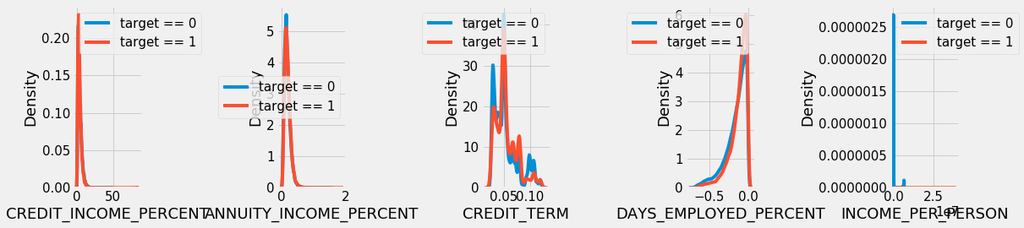

```python
# kdeplot for these five newly added features
```

```python
submission, fi, metrics = model(train, test)
print('Baseline metrics')
print(metrics)
```

```
Training Data Shape:  (307511, 367)
Testing Data Shape:  (48744, 367)
Training until validation scores don't improve for 100 rounds.
[200]	valid's auc: 0.784635	train's auc: 0.832546
[400]	valid's auc: 0.786757	train's auc: 0.869821
Early stopping, best iteration is:
[434]	valid's auc: 0.786885	train's auc: 0.875206
Training until validation scores don't improve for 100 rounds.
[200]	valid's auc: 0.790108	train's auc: 0.831366
[400]	valid's auc: 0.791853	train's auc: 0.869256
Early stopping, best iteration is:
[332]	valid's auc: 0.792118	train's auc: 0.857459
Training until validation scores don't improve for 100 rounds.
[200]	valid's auc: 0.77998	train's auc: 0.832735
[400]	valid's auc: 0.782628	train's auc: 0.869848
[600]	valid's auc: 0.783345	train's auc: 0.898427
Early stopping, best iteration is:
[632]	valid's auc: 0.783453	train's auc: 0.902175
Training until validation scores don't improve for 100 rounds.
[200]	valid's auc: 0.786331	train's auc: 0.831629
[400]	valid's auc: 0.787704	train's auc: 0.868894
[600]	valid's auc: 0.787575	train's auc: 0.897128
Early stopping, best iteration is:
[522]	valid's auc: 0.787899	train's auc: 0.886935
Training until validation scores don't improve for 100 rounds.
[200]	valid's auc: 0.787	train's auc: 0.831555
[400]	valid's auc: 0.788937	train's auc: 0.868572
Early stopping, best iteration is:
[451]	valid's auc: 0.789372	train's auc: 0.876422
Baseline metrics
      fold     train     valid
0        0  0.875206  0.786885
1        1  0.857459  0.792118
2        2  0.902175  0.783453
3        3  0.886935  0.787899
4        4  0.876422  0.789372
5  overall  0.879639  0.787708
```

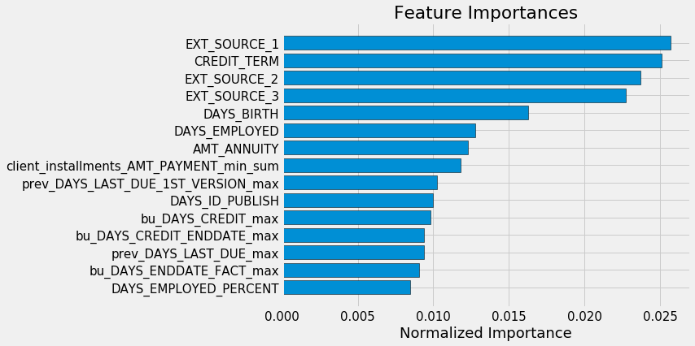

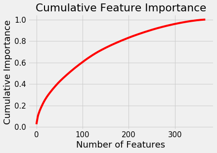

```
292 features required for 0.95 of cumulative importance
```

```python
fi_sorted = plot_feature_importances(fi,0.95)
```

We can see the AUC is **increased from 0.785135 to 0.787708**. In the top 15 important features, **CREDIT_TERM** and **DAYS_EMPLOYED_PERCENT** are among the five new features built in this section. Additionally, 8 out of the 15-feature list are from my creation. It means the feature engineering is very important to be implemented.

Let's further reduce the feature size by limit to 95% cumulative feature importance.

```python
# Threshold for cumulative importance
threshold = 0.95

# Extract the features to keep
features_to_keep = list(fi_sorted[fi_sorted['cumulative_importance'] < threshold]['feature'])

# Create new datasets with smaller features
train_small = train[features_to_keep]
test_small = test[features_to_keep]
```

```python
train_small['TARGET'] = train_target
train_small['SK_ID_CURR'] = train_id_curr
test_small['SK_ID_CURR'] = test_id_curr
```

```python
submission, fi, metrics = model(train_small, test_small)
print('Baseline metrics')
print(metrics)
```

```
Training Data Shape:  (307511, 291)
Testing Data Shape:  (48744, 291)
Training until validation scores don't improve for 100 rounds.
[200]	valid's auc: 0.784574	train's auc: 0.831762
[400]	valid's auc: 0.786412	train's auc: 0.869211
Early stopping, best iteration is:
[403]	valid's auc: 0.786423	train's auc: 0.869693
Training until validation scores don't improve for 100 rounds.
[200]	valid's auc: 0.788853	train's auc: 0.830927
[400]	valid's auc: 0.79098	train's auc: 0.868905
Early stopping, best iteration is:
[405]	valid's auc: 0.791095	train's auc: 0.869802
Training until validation scores don't improve for 100 rounds.
[200]	valid's auc: 0.780302	train's auc: 0.832474
[400]	valid's auc: 0.782857	train's auc: 0.8697
Early stopping, best iteration is:
[417]	valid's auc: 0.78309	train's auc: 0.872447
Training until validation scores don't improve for 100 rounds.
[200]	valid's auc: 0.786183	train's auc: 0.831359
[400]	valid's auc: 0.787985	train's auc: 0.868722
Early stopping, best iteration is:
[456]	valid's auc: 0.788413	train's auc: 0.877214
Training until validation scores don't improve for 100 rounds.
[200]	valid's auc: 0.787731	train's auc: 0.831206
[400]	valid's auc: 0.789397	train's auc: 0.868792
Early stopping, best iteration is:
[404]	valid's auc: 0.789441	train's auc: 0.869382
Baseline metrics
      fold     train     valid
0        0  0.869693  0.786423
1        1  0.869802  0.791095
2        2  0.872447  0.783090
3        3  0.877214  0.788413
4        4  0.869382  0.789441
5  overall  0.871707  0.787704
```

We can see the smaller 292 features by keeping 95% cumulative feature importance have almost the same AUC performace of 0.787704. Thus we need to keep it.

### 3.3 Time processing for installment payment data frame

The installments_payments data contains information on each payment made on the previous loans at Home Credit. It has two date offset columns:

- **DAYS_INSTALMENT**: number of days before current application at Home Credit that previous installment was supposed to be paid
- **DAYS_ENTRY_PAYMENT**: number of days before current application at Home Credit that previous installment was actually paid

Thus build a flag column to indicate whether the loan is late paid. Also, other feautures on the mutual relations are built.

```python
ins_pay['LATE_PAYMENT'] = ((pd.to_timedelta(ins_pay['DAYS_ENTRY_PAYMENT'], 'D') -
                            pd.to_timedelta(ins_pay['DAYS_INSTALMENT'], 'D')).astype(int)
                           > 0).astype(int).astype('object')
```

```python
ins_pay['PAYMENT_PERC'] = ins_pay['AMT_PAYMENT'] / ins_pay['AMT_INSTALMENT']
ins_pay['PAYMENT_DIFF'] = ins_pay['AMT_INSTALMENT'] - ins_pay['AMT_PAYMENT']
# Days past due and days before due (no negative values)
ins_pay['DPD'] = ins_pay['DAYS_ENTRY_PAYMENT'] - ins_pay['DAYS_INSTALMENT']
ins_pay['DBD'] = ins_pay['DAYS_INSTALMENT'] - ins_pay['DAYS_ENTRY_PAYMENT']
ins_pay['DPD'] = ins_pay['DPD'].apply(lambda x: x if x > 0 else 0)
ins_pay['DBD'] = ins_pay['DBD'].apply(lambda x: x if x > 0 else 0)
```

```python
ins_pay.head()
```

|  | SK_ID_PREV | SK_ID_CURR | LATE_PAYMENT | PAYMENT_PERC | PAYMENT_DIFF | DPD | DBD |
| --- | --- | --- | --- | --- | --- | --- | --- |
| 0 | 1054186 | 161674 | 0 | 1.000000 | 0.000 | 0.0 | 7.0 |
| 1 | 1330831 | 151639 | 0 | 1.000000 | 0.000 | 0.0 | 0.0 |
| 2 | 2085231 | 193053 | 0 | 1.000000 | 0.000 | 0.0 | 0.0 |
| 3 | 2452527 | 199697 | 0 | 1.000000 | 0.000 | 0.0 | 8.0 |
| 4 | 2714724 | 167756 | 1 | 0.997942 | 4.455 | 17.0 | 0.0 |

After numeric aggregation functio processed, the newly merged data frame increase the feature number from 292 to 317.

```python
ins_pay_2 = agg_numeric(ins_pay, 'SK_ID_CURR', 'ins')
```

```python
train = train.merge(ins_pay_1, on = 'SK_ID_CURR', how = 'left')
test = test.merge(ins_pay_1, on = 'SK_ID_CURR', how = 'left')
train = train.merge(ins_pay_2, on = 'SK_ID_CURR', how = 'left')
test = test.merge(ins_pay_2, on = 'SK_ID_CURR', how = 'left')
```

```python
print('Training shape: ', train.shape)
print('Testing shape: ', test.shape)
```

```
Training shape:  (307511, 318)
Testing shape:  (48744, 317)
```

### 3.4 Features created by others shared from the kernels (Option)

These features are created by learning from kernels shared by others in Kaggle platform.

```python
inc_by_org = cc[['AMT_INCOME_TOTAL', 'ORGANIZATION_TYPE']].groupby('ORGANIZATION_TYPE').median()['AMT_INCOME_TOTAL']
train['NEW_CREDIT_TO_ANNUITY_RATIO'] = cc['AMT_CREDIT'] / cc['AMT_ANNUITY']
train['NEW_CREDIT_TO_GOODS_RATIO'] = cc['AMT_CREDIT'] / cc['AMT_GOODS_PRICE']
train['NEW_INC_PER_CHLD'] = cc['AMT_INCOME_TOTAL'] / (1 + cc['CNT_CHILDREN'])
train['NEW_INC_BY_ORG'] = cc['ORGANIZATION_TYPE'].map(inc_by_org)
train['NEW_EMPLOY_TO_BIRTH_RATIO'] = train['DAYS_EMPLOYED'] / train['DAYS_BIRTH']
train['NEW_ANNUITY_TO_INCOME_RATIO'] = cc['AMT_ANNUITY'] / (1 + train['AMT_INCOME_TOTAL'])
train['NEW_SOURCES_PROD'] = train['EXT_SOURCE_1'] * train['EXT_SOURCE_2'] * train['EXT_SOURCE_3']
train['NEW_EXT_SOURCES_MEAN'] = train[['EXT_SOURCE_1', 'EXT_SOURCE_2', 'EXT_SOURCE_3']].mean(axis=1)
train['NEW_SCORES_STD'] = train[['EXT_SOURCE_1', 'EXT_SOURCE_2', 'EXT_SOURCE_3']].std(axis=1)
train['NEW_SCORES_STD'] = train['NEW_SCORES_STD'].fillna(train['NEW_SCORES_STD'].mean())
train['NEW_CAR_TO_BIRTH_RATIO'] = train['OWN_CAR_AGE'] / train['DAYS_BIRTH']
train['NEW_CAR_TO_EMPLOY_RATIO'] = train['OWN_CAR_AGE'] / train['DAYS_EMPLOYED']
train['NEW_PHONE_TO_BIRTH_RATIO'] = train['DAYS_LAST_PHONE_CHANGE'] / train['DAYS_BIRTH']
train['NEW_PHONE_TO_EMPLOY_RATIO'] = train['DAYS_LAST_PHONE_CHANGE'] / train['DAYS_EMPLOYED']
train['NEW_CREDIT_TO_INCOME_RATIO'] = train['AMT_CREDIT'] / train['AMT_INCOME_TOTAL']
train['NEW_DOC_IND_AVG'] = cc[docs].mean(axis=1)
train['NEW_DOC_IND_STD'] = cc[docs].std(axis=1)
train['NEW_DOC_IND_KURT'] = cc[docs].kurtosis(axis=1)
train['NEW_LIVE_IND_SUM'] = cc[live].sum(axis=1)
train['NEW_LIVE_IND_STD'] = cc[live].std(axis=1)
```

#### Application

```python
train['app missing'] = cc.isnull().sum(axis = 1).values

train['app EXT_SOURCE std'] = cc[['EXT_SOURCE_1', 'EXT_SOURCE_2', 'EXT_SOURCE_3']].std(axis = 1)
train['app EXT_SOURCE prod'] = cc['EXT_SOURCE_1'] * cc['EXT_SOURCE_2'] * cc['EXT_SOURCE_3']
train['app EXT_SOURCE_1 * EXT_SOURCE_2'] = cc['EXT_SOURCE_1'] * cc['EXT_SOURCE_2']
train['app EXT_SOURCE_1 * EXT_SOURCE_3'] = cc['EXT_SOURCE_1'] * cc['EXT_SOURCE_3']
train['app EXT_SOURCE_2 * EXT_SOURCE_3'] = cc['EXT_SOURCE_2'] * cc['EXT_SOURCE_3']
train['app EXT_SOURCE_1 * DAYS_EMPLOYED'] = cc['EXT_SOURCE_1'] * cc['DAYS_EMPLOYED']
train['app EXT_SOURCE_2 * DAYS_EMPLOYED'] = cc['EXT_SOURCE_2'] * cc['DAYS_EMPLOYED']
train['app EXT_SOURCE_3 * DAYS_EMPLOYED'] = cc['EXT_SOURCE_3'] * cc['DAYS_EMPLOYED']
train['app EXT_SOURCE_1 / DAYS_BIRTH'] = cc['EXT_SOURCE_1'] / cc['DAYS_BIRTH']
train['app EXT_SOURCE_2 / DAYS_BIRTH'] = cc['EXT_SOURCE_2'] / cc['DAYS_BIRTH']
train['app EXT_SOURCE_3 / DAYS_BIRTH'] = cc['EXT_SOURCE_3'] / cc['DAYS_BIRTH']

train['app AMT_CREDIT - AMT_GOODS_PRICE'] = cc['AMT_CREDIT'] - cc['AMT_GOODS_PRICE']
train['app AMT_CREDIT / AMT_GOODS_PRICE'] = cc['AMT_CREDIT'] / cc['AMT_GOODS_PRICE']
train['app AMT_CREDIT / AMT_ANNUITY'] = cc['AMT_CREDIT'] / cc['AMT_ANNUITY']
train['app AMT_CREDIT / AMT_INCOME_TOTAL'] = cc['AMT_CREDIT'] / cc['AMT_INCOME_TOTAL']

train['app AMT_INCOME_TOTAL / 12 - AMT_ANNUITY'] = cc['AMT_INCOME_TOTAL'] / 12. - cc['AMT_ANNUITY']
train['app AMT_INCOME_TOTAL / AMT_ANNUITY'] = cc['AMT_INCOME_TOTAL'] / cc['AMT_ANNUITY']
train['app AMT_INCOME_TOTAL - AMT_GOODS_PRICE'] = cc['AMT_INCOME_TOTAL'] - cc['AMT_GOODS_PRICE']
train['app AMT_INCOME_TOTAL / CNT_FAM_MEMBERS'] = cc['AMT_INCOME_TOTAL'] / cc['CNT_FAM_MEMBERS']
train['app AMT_INCOME_TOTAL / CNT_CHILDREN'] = cc['AMT_INCOME_TOTAL'] / (1 + cc['CNT_CHILDREN'])

train['app most popular AMT_GOODS_PRICE'] = cc['AMT_GOODS_PRICE'] \
                .isin([225000, 450000, 675000, 900000]).map({True: 1, False: 0})
train['app popular AMT_GOODS_PRICE'] = cc['AMT_GOODS_PRICE'] \
                .isin([1125000, 1350000, 1575000, 1800000, 2250000]).map({True: 1, False: 0})

train['app OWN_CAR_AGE / DAYS_BIRTH'] = train['OWN_CAR_AGE'] / train['DAYS_BIRTH']
train['app OWN_CAR_AGE / DAYS_EMPLOYED'] = train['OWN_CAR_AGE'] / train['DAYS_EMPLOYED']

train['app DAYS_LAST_PHONE_CHANGE / DAYS_BIRTH'] = train['DAYS_LAST_PHONE_CHANGE'] / train['DAYS_BIRTH']
train['app DAYS_LAST_PHONE_CHANGE / DAYS_EMPLOYED'] = train['DAYS_LAST_PHONE_CHANGE'] / train['DAYS_EMPLOYED']
train['app DAYS_EMPLOYED - DAYS_BIRTH'] = train['DAYS_EMPLOYED'] - train['DAYS_BIRTH']
train['app DAYS_EMPLOYED / DAYS_BIRTH'] = train['DAYS_EMPLOYED'] / train['DAYS_BIRTH']

train['app CNT_CHILDREN / CNT_FAM_MEMBERS'] = cc['CNT_CHILDREN'] / cc['CNT_FAM_MEMBERS']
```

#### Bureau

```python
df_bureau.loc[df_bureau['AMT_ANNUITY'] > .8e8, 'AMT_ANNUITY'] = np.nan
df_bureau.loc[df_bureau['AMT_CREDIT_SUM'] > 3e8, 'AMT_CREDIT_SUM'] = np.nan
df_bureau.loc[df_bureau['AMT_CREDIT_SUM_DEBT'] > 1e8, 'AMT_CREDIT_SUM_DEBT'] = np.nan
df_bureau.loc[df_bureau['AMT_CREDIT_MAX_OVERDUE'] > .8e8, 'AMT_CREDIT_MAX_OVERDUE'] = np.nan
df_bureau.loc[df_bureau['DAYS_ENDDATE_FACT'] < -10000, 'DAYS_ENDDATE_FACT'] = np.nan
df_bureau.loc[(df_bureau['DAYS_CREDIT_UPDATE'] > 0) | (df_bureau['DAYS_CREDIT_UPDATE'] < -40000), 'DAYS_CREDIT_UPDATE'] = np.nan
df_bureau.loc[df_bureau['DAYS_CREDIT_ENDDATE'] < -10000, 'DAYS_CREDIT_ENDDATE'] = np.nan

df_bureau.drop(df_bureau[df_bureau['DAYS_ENDDATE_FACT'] < df_bureau['DAYS_CREDIT']].index, inplace = True)
```

```python
df = pd.DataFrame()
df['bureau AMT_CREDIT_SUM - AMT_CREDIT_SUM_DEBT'] = df_bureau['AMT_CREDIT_SUM'] - df_bureau['AMT_CREDIT_SUM_DEBT']
df['bureau AMT_CREDIT_SUM - AMT_CREDIT_SUM_LIMIT'] = df_bureau['AMT_CREDIT_SUM'] - df_bureau['AMT_CREDIT_SUM_LIMIT']
df['bureau AMT_CREDIT_SUM - AMT_CREDIT_SUM_OVERDUE'] = df_bureau['AMT_CREDIT_SUM'] - df_bureau['AMT_CREDIT_SUM_OVERDUE']

df['bureau DAYS_CREDIT - CREDIT_DAY_OVERDUE'] = df_bureau['DAYS_CREDIT'] - df_bureau['CREDIT_DAY_OVERDUE']
df['bureau DAYS_CREDIT - DAYS_CREDIT_ENDDATE'] = df_bureau['DAYS_CREDIT'] - df_bureau['DAYS_CREDIT_ENDDATE']
df['bureau DAYS_CREDIT - DAYS_ENDDATE_FACT'] = df_bureau['DAYS_CREDIT'] - df_bureau['DAYS_ENDDATE_FACT']
df['bureau DAYS_CREDIT_ENDDATE - DAYS_ENDDATE_FACT'] = df_bureau['DAYS_CREDIT_ENDDATE'] - df_bureau['DAYS_ENDDATE_FACT']
df['bureau DAYS_CREDIT_UPDATE - DAYS_CREDIT_ENDDATE'] = df_bureau['DAYS_CREDIT_UPDATE'] - df_bureau['DAYS_CREDIT_ENDDATE']
```

#### Previous_application

```python
# Replace some outliers
df_prev.loc[df_prev['AMT_CREDIT'] > 6000000, 'AMT_CREDIT'] = np.nan
df_prev.loc[df_prev['SELLERPLACE_AREA'] > 3500000, 'SELLERPLACE_AREA'] = np.nan
df_prev[['DAYS_FIRST_DRAWING', 'DAYS_FIRST_DUE', 'DAYS_LAST_DUE_1ST_VERSION',
        'DAYS_LAST_DUE', 'DAYS_TERMINATION']].replace(365243, np.nan, inplace = True)
```

```python
# Some new features
df = pd.DataFrame()

df['prev missing'] = df_prev.isnull().sum(axis = 1).values
df['prev AMT_APPLICATION / AMT_CREDIT'] = df_prev['AMT_APPLICATION'] / df_prev['AMT_CREDIT']
df['prev AMT_APPLICATION - AMT_CREDIT'] = df_prev['AMT_APPLICATION'] - df_prev['AMT_CREDIT']
df['prev AMT_APPLICATION - AMT_GOODS_PRICE'] = df_prev['AMT_APPLICATION'] - df_prev['AMT_GOODS_PRICE']
df['prev AMT_GOODS_PRICE - AMT_CREDIT'] = df_prev['AMT_GOODS_PRICE'] - df_prev['AMT_CREDIT']
df['prev DAYS_FIRST_DRAWING - DAYS_FIRST_DUE'] = df_prev['DAYS_FIRST_DRAWING'] - df_prev['DAYS_FIRST_DUE']
df['prev DAYS_TERMINATION less -500'] = (df_prev['DAYS_TERMINATION'] < -500).astype(int)
```

#### Pos_cash

```python
# Replace some outliers
df_pos.loc[df_pos['CNT_INSTALMENT_FUTURE'] > 60, 'CNT_INSTALMENT_FUTURE'] = np.nan

# Some new features
df = pd.DataFrame()
df['pos CNT_INSTALMENT more CNT_INSTALMENT_FUTURE'] = \
                (df_pos['CNT_INSTALMENT'] > df_pos['CNT_INSTALMENT_FUTURE']).astype(int)
```

#### Installment_payments

```python
# Replace some outliers
df_ins.loc[df_ins['NUM_INSTALMENT_VERSION'] > 70, 'NUM_INSTALMENT_VERSION'] = np.nan
df_ins.loc[df_ins['DAYS_ENTRY_PAYMENT'] < -4000, 'DAYS_ENTRY_PAYMENT'] = np.nan
```

```python
# Some new features
df = pd.DataFrame()

df['ins NUM_INSTALMENT_NUMBER_100'] = (df_ins['NUM_INSTALMENT_NUMBER'] == 100).astype(int)
df['ins DAYS_INSTALMENT more NUM_INSTALMENT_NUMBER'] = (df_ins['DAYS_INSTALMENT'] > df_ins['NUM_INSTALMENT_NUMBER'] * 50 / 3 - 11500 / 3).astype(int)
```

#### Credit card

```python
# Some new features
df = pd.DataFrame()

df['card missing'] = df_card.isnull().sum(axis = 1).values
df['card SK_DPD - MONTHS_BALANCE'] = df_card['SK_DPD'] - df_card['MONTHS_BALANCE']
df['card SK_DPD_DEF - MONTHS_BALANCE'] = df_card['SK_DPD_DEF'] - df_card['MONTHS_BALANCE']
df['card SK_DPD - SK_DPD_DEF'] = df_card['SK_DPD'] - df_card['SK_DPD_DEF']

df['card AMT_TOTAL_RECEIVABLE - AMT_RECIVABLE'] = df_card['AMT_TOTAL_RECEIVABLE'] - df_card['AMT_RECIVABLE']
df['card AMT_TOTAL_RECEIVABLE - AMT_RECEIVABLE_PRINCIPAL'] = df_card['AMT_TOTAL_RECEIVABLE'] - df_card['AMT_RECEIVABLE_PRINCIPAL']
df['card AMT_RECIVABLE - AMT_RECEIVABLE_PRINCIPAL'] = df_card['AMT_RECIVABLE'] - df_card['AMT_RECEIVABLE_PRINCIPAL']

df['card AMT_BALANCE - AMT_RECIVABLE'] = df_card['AMT_BALANCE'] - df_card['AMT_RECIVABLE']
df['card AMT_BALANCE - AMT_RECEIVABLE_PRINCIPAL'] = df_card['AMT_BALANCE'] - df_card['AMT_RECEIVABLE_PRINCIPAL']
df['card AMT_BALANCE - AMT_TOTAL_RECEIVABLE'] = df_card['AMT_BALANCE'] - df_card['AMT_TOTAL_RECEIVABLE']

df['card AMT_DRAWINGS_CURRENT - AMT_DRAWINGS_ATM_CURRENT'] = df_card['AMT_DRAWINGS_CURRENT'] - df_card['AMT_DRAWINGS_ATM_CURRENT']
df['card AMT_DRAWINGS_CURRENT - AMT_DRAWINGS_OTHER_CURRENT'] = df_card['AMT_DRAWINGS_CURRENT'] - df_card['AMT_DRAWINGS_OTHER_CURRENT']
df['card AMT_DRAWINGS_CURRENT - AMT_DRAWINGS_POS_CURRENT'] = df_card['AMT_DRAWINGS_CURRENT'] - df_card['AMT_DRAWINGS_POS_CURRENT']
```

```python
print('Training shape: ', train.shape)
print('Testing shape: ', test.shape)
```

```
Training shape:  (307511, 523)
Testing shape:  (48744, 522)
```

#### Feature selection

```python
submission2, fi2, metrics2 = model(train_small, test_small)
print('Baseline metrics')
print(metrics2)
```

```
Training Data Shape:  (307511, 345)
Testing Data Shape:  (48744, 345)
Training until validation scores don't improve for 100 rounds.
[200]	valid's auc: 0.786717	train's auc: 0.836282
[400]	valid's auc: 0.788608	train's auc: 0.874879
Early stopping, best iteration is:
[415]	valid's auc: 0.788788	train's auc: 0.87719
Training until validation scores don't improve for 100 rounds.
[200]	valid's auc: 0.791636	train's auc: 0.835793
[400]	valid's auc: 0.794264	train's auc: 0.874482
[600]	valid's auc: 0.794265	train's auc: 0.903425
Early stopping, best iteration is:
[528]	valid's auc: 0.794677	train's auc: 0.893981
Training until validation scores don't improve for 100 rounds.
[200]	valid's auc: 0.783007	train's auc: 0.837092
[400]	valid's auc: 0.785807	train's auc: 0.875477
Early stopping, best iteration is:
[384]	valid's auc: 0.785864	train's auc: 0.872876
Training until validation scores don't improve for 100 rounds.
[200]	valid's auc: 0.788905	train's auc: 0.836535
[400]	valid's auc: 0.790713	train's auc: 0.874565
Early stopping, best iteration is:
[405]	valid's auc: 0.790764	train's auc: 0.875347
Training until validation scores don't improve for 100 rounds.
[200]	valid's auc: 0.790666	train's auc: 0.835822
[400]	valid's auc: 0.793088	train's auc: 0.873836
[600]	valid's auc: 0.793505	train's auc: 0.902574
Early stopping, best iteration is:
[613]	valid's auc: 0.79366	train's auc: 0.904141
Baseline metrics
      fold     train     valid
0        0  0.877190  0.788788
1        1  0.893981  0.794677
2        2  0.872876  0.785864
3        3  0.875347  0.790764
4        4  0.904141  0.793660
5  overall  0.884707  0.790696
```

## 4. Model tuning

By manually tuning parameters due to the time and computing resources, the overall AUC increases from 0.790696 to **0.793270** using the 345 features set. Finnaly it reaches top 30% of the Kaggle leaderboard ranking.

```python
# model = lgb.LGBMClassifier(n_estimators=10000,
#                objective = 'binary',
#                boosting_type='gbdt',
#                class_weight = 'balanced',
#                learning_rate = 0.02,
#                colsample_bytree = 0.9497036,
#                subsample = 0.8715623,
#                subsample_freq = 1,
#                max_depth = 8,
#                reg_alpha = 0.041545473,
#                reg_lambda = 0.0735294,
#                min_split_gain = 0.0222415,
#                min_child_weight = 60, # 39.3259775,
#                num_leaves = 20,
#                n_jobs = -1,
#                random_state = 50)
```

```python
submission2, fi2, metrics2 = model(train, test)
print('Baseline metrics')
print(metrics2)
```

```
Training Data Shape:  (307511, 345)
Testing Data Shape:  (48744, 345)
Training until validation scores don't improve for 200 rounds.
[200]	valid's auc: 0.773212	train's auc: 0.790603
[400]	valid's auc: 0.78398	train's auc: 0.810805
[600]	valid's auc: 0.788035	train's auc: 0.824664
[800]	valid's auc: 0.789932	train's auc: 0.835956
[1000]	valid's auc: 0.790819	train's auc: 0.846099
[1200]	valid's auc: 0.791263	train's auc: 0.855229
[1400]	valid's auc: 0.791509	train's auc: 0.863827
[1600]	valid's auc: 0.791583	train's auc: 0.87187
Early stopping, best iteration is:
[1479]	valid's auc: 0.791671	train's auc: 0.86705
Training until validation scores don't improve for 200 rounds.
[200]	valid's auc: 0.776425	train's auc: 0.789751
[400]	valid's auc: 0.787609	train's auc: 0.809798
[600]	valid's auc: 0.791837	train's auc: 0.823831
[800]	valid's auc: 0.793398	train's auc: 0.835166
[1000]	valid's auc: 0.794367	train's auc: 0.845455
[1200]	valid's auc: 0.795042	train's auc: 0.854834
[1400]	valid's auc: 0.795469	train's auc: 0.86355
[1600]	valid's auc: 0.795706	train's auc: 0.871515
[1800]	valid's auc: 0.796031	train's auc: 0.878983
[2000]	valid's auc: 0.795965	train's auc: 0.88613
Early stopping, best iteration is:
[1933]	valid's auc: 0.796117	train's auc: 0.883795
Training until validation scores don't improve for 200 rounds.
[200]	valid's auc: 0.768201	train's auc: 0.791394
[400]	valid's auc: 0.779305	train's auc: 0.81159
[600]	valid's auc: 0.783941	train's auc: 0.825338
[800]	valid's auc: 0.785854	train's auc: 0.836761
[1000]	valid's auc: 0.786979	train's auc: 0.84671
[1200]	valid's auc: 0.787733	train's auc: 0.85596
[1400]	valid's auc: 0.788041	train's auc: 0.864442
[1600]	valid's auc: 0.78852	train's auc: 0.872291
[1800]	valid's auc: 0.788778	train's auc: 0.879821
Early stopping, best iteration is:
[1759]	valid's auc: 0.788847	train's auc: 0.878321
Training until validation scores don't improve for 200 rounds.
[200]	valid's auc: 0.776449	train's auc: 0.790195
```

[output cut: 21 more lines]

```
[2000]	valid's auc: 0.796519	train's auc: 0.885442
[2200]	valid's auc: 0.796641	train's auc: 0.891974
[2400]	valid's auc: 0.796708	train's auc: 0.898095
[2600]	valid's auc: 0.796711	train's auc: 0.903889
[2800]	valid's auc: 0.796683	train's auc: 0.909384
Early stopping, best iteration is:
[2684]	valid's auc: 0.796783	train's auc: 0.906178
Baseline metrics
      fold     train     valid
0        0  0.867050  0.791671
1        1  0.883795  0.796117
2        2  0.878321  0.788847
3        3  0.882303  0.793259
4        4  0.906178  0.796783
5  overall  0.883529  0.793270
```

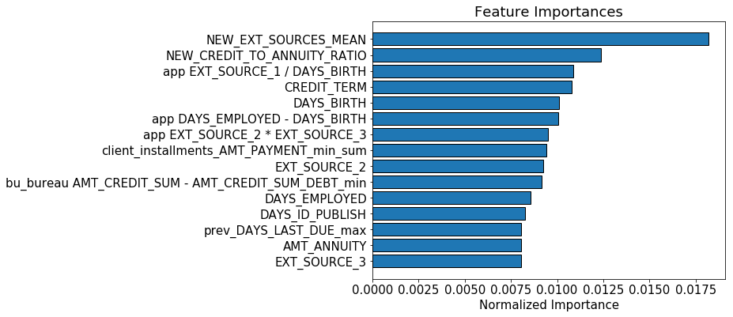

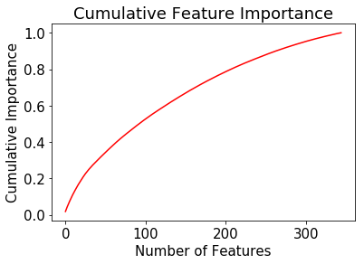

```
300 features required for 0.95 of cumulative importance
```

```python
fi_sorted = plot_feature_importances(fi2,0.95)
```